# Network IDS (NSL-KDD dataset)

Jimmy Azar

# Introduction

We build a network intrusion detection system based on the relative density one-class classifier (RDOCC) and the median one-class classifier (MOCC). We address both binary classification (normal-vs-attack), and multi-class classification with classes representing normal cases, probing attacks, DoS attacks, U2R attacks, and R2L attacks. The multi-class situation is handled by constructing 5 one-class classifiers followed by a majority voting scheme.

# Data preparation

## Load network data

Read in network traffic data (NSL-KDD dataset). The training and test set data are a modified version of the original KDD’99 release.

```r
rm(list=ls())
set.seed(123)
#data_trn <- read.table("KDDTrain+_20Percent.txt", sep = ",")
data_trn <- read.table("KDDTrain+.txt", sep = ",")
data_tst <- read.table("KDDTest+.txt", sep = ",")

data_trn[1,] #show one instance
```

```
##   V1  V2       V3 V4  V5 V6 V7 V8 V9 V10 V11 V12 V13 V14 V15 V16 V17 V18 V19
## 1  0 tcp ftp_data SF 491  0  0  0  0   0   0   0   0   0   0   0   0   0   0
##   V20 V21 V22 V23 V24 V25 V26 V27 V28 V29 V30 V31 V32 V33  V34  V35  V36 V37
## 1   0   0   0   2   2   0   0   0   0   1   0   0 150  25 0.17 0.03 0.17   0
##   V38 V39  V40 V41    V42 V43
## 1   0   0 0.05   0 normal  20
```

```r
#remove last column on #successfulPrediction (out of 21 learners)
data_trn <- data_trn[,-43]
data_tst <- data_tst[,-43]
```

## Rename features

Assign column (attribute) names according to dataset description.

```r
#rename features/columns
feature_names <- c("duration","protocol_type","service","flag","src_bytes","dst_bytes",
                   "land","wrong_fragment","urgent","hot","num_failed_logins","logged_in",
                   "num_compromised","root_shell","su_attempted","num_root",
                   "num_file_creations","num_shells","num_access_files",
                   "num_outbound_cmds","is_host_login","is_guest_login","count",
                   "srv_count","serror_rate", "srv_serror_rate","rerror_rate",
                   "srv_rerror_rate","same_srv_rate","diff_srv_rate","srv_diff_host_rate",
                   "dst_host_count","dst_host_srv_count","dst_host_same_srv_rate",
                   "dst_host_diff_srv_rate","dst_host_same_src_port_rate",
                   "dst_host_srv_diff_host_rate","dst_host_serror_rate",
                   "dst_host_srv_serror_rate","dst_host_rerror_rate",
                   "dst_host_srv_rerror_rate","attack")

colnames(data_trn) <- feature_names
colnames(data_tst) <- feature_names
```

## Extract and show labels

Extract labels from the attribute `attack` for the training set and test set, and print the labels with their frequency of occurrence.

```r
#extract unique labels
ltrn <- unique(data_trn[,"attack"]) #training labels
ltst <- unique(data_tst[,"attack"]) #test labels
#print(ltrn)
#print(ltst)
```

## Training set labels

```r
#print frequency table for labels
df <- as.data.frame(table(data_trn[,"attack"]))
colnames(df) <- c("label","frequency")
print(df,row.names = TRUE)
```

```
##              label frequency
## 1             back       956
## 2  buffer_overflow        30
## 3        ftp_write         8
## 4     guess_passwd        53
## 5             imap        11
## 6          ipsweep      3599
## 7             land        18
## 8       loadmodule         9
## 9         multihop         7
## 10         neptune     41214
## 11            nmap      1493
## 12          normal     67343
## 13            perl         3
## 14             phf         4
## 15             pod       201
## 16       portsweep      2931
## 17         rootkit        10
## 18           satan      3633
## 19           smurf      2646
## 20             spy         2
## 21        teardrop       892
## 22     warezclient       890
## 23     warezmaster        20
```

## Test set labels

```r
df <- as.data.frame(table(data_tst[,"attack"]))
colnames(df) <- c("label","frequency")
print(df,row.names = TRUE)
```

```
##              label frequency
## 1          apache2       737
## 2             back       359
## 3  buffer_overflow        20
## 4        ftp_write         3
## 5     guess_passwd      1231
## 6       httptunnel       133
## 7             imap         1
## 8          ipsweep       141
## 9             land         7
## 10      loadmodule         2
## 11        mailbomb       293
## 12           mscan       996
## 13        multihop        18
## 14           named        17
```

[output cut: 24 more lines]

## Add a binary label (attack/normal)

For each instance, add a binary label, `Lb`,specifying whether the object represents normal network traffic or an attack (anomaly). An anomaly can be any one of the attack labels that are different than “normal”. An anomaly is represented by the label “1” and a normal instance by the label “0”.

```r
#add binary label for normal (0) or anomaly (1)
Lb <- as.numeric(data_trn$attack != "normal")
data_trn$Lb <- Lb
print(as.data.frame(table(Lb)), row.names = FALSE)
```

```
##  Lb  Freq
##   0 67343
##   1 58630
```

```r
Lb <- as.numeric(data_tst$attack != "normal")
data_tst$Lb <- Lb
print(as.data.frame(table(Lb)), row.names = FALSE)
```

```
##  Lb  Freq
##   0  9711
##   1 12833
```

## Count duplicate observations

The NSL-KDD datset contains no duplicate instances; we check this fact below.

## Duplicate observations in training set

```r
#count duplicate rows/observations
d <- duplicated(data_trn)
#length(d) #number of obs.
#sum(d) #number of duplicates
distinct_trn <- length(d) - sum(d)

d_attack <- duplicated(data_trn[data_trn$Lb==1,])
#length(d_attack)
#sum(d_attack)
distinct_trn_attack <- length(d_attack) - sum(d_attack)

d_normal <- duplicated(data_trn[data_trn$Lb==0,])
#length(d_normal)
#sum(d_normal)
distinct_trn_normal <- length(d_normal) - sum(d_normal)

#print table summary
df <- data.frame(original_obs = c(length(d_attack),length(d_normal),length(d)),
                 distinct_obs = c(distinct_trn_attack,distinct_trn_normal,distinct_trn))
df$reduction_rate <- (df$original_obs - df$distinct_obs)/df$original_obs * 100
row.names(df) <- c("Attacks","Normal","Total")
print(df)
```

```
##         original_obs distinct_obs reduction_rate
## Attacks        58630        58630              0
## Normal         67343        67343              0
## Total         125973       125973              0
```

## Duplicate observations in test set

```r
#repeat for test set
d <- duplicated(data_tst)
#length(d)
#sum(d)
distinct_tst <- length(d) - sum(d)

d_attack <- duplicated(data_tst[data_tst$Lb==1,])
#length(d_attack)
#sum(d_attack)
distinct_tst_attack <- length(d_attack) - sum(d_attack)

d_normal <- duplicated(data_tst[data_tst$Lb==0,])
#length(d_normal)
#sum(d_normal)
distinct_tst_normal <- length(d_normal) - sum(d_normal)

#print table summary
df <- data.frame(original_obs = c(length(d_attack),length(d_normal),length(d)),
                 distinct_obs = c(distinct_tst_attack,distinct_tst_normal,distinct_tst))
df$reduction_rate <- (df$original_obs - df$distinct_obs)/df$original_obs * 100
row.names(df) <- c("Attacks","Normal","Total")
print(df)
```

```
##         original_obs distinct_obs reduction_rate
## Attacks        12833        12833              0
## Normal          9711         9711              0
## Total          22544        22544              0
```

## One-hot encoding of nominal features

To perform one-hot encoding of features, the training set and test set are first combined since the test set contains additional levels (categories) for some features. Such levels are not apparent in the training set. Once the combined data is encoded, the training set and test test are then re-split.

```r
#One-hot encoding of nominal features
if (!require("e1071")) install.packages("e1071")
if (!require("caret")) install.packages("caret")
library(e1071)
library(caret)

Strn <- data_trn[,-42] #remove attack var
Stst <- data_tst[,-42] #remove attack var
flg <- dim(Strn)[1]
Comb <- rbind(Strn,Stst)
dmy <- dummyVars(" ~ .", data = Comb)
Comb <- data.frame(predict(dmy, newdata = Comb))
#colnames(Comb)

Strn <- Comb[1:flg,]
Stst <- Comb[-c(1:flg),]
```

# Binary classification

In this section, we train the relative density one-class classifier (RDOCC) to differentiate between normal network traffic data and attacks.

## Normalization

We begin by normalizing the data based on the training set and dropping any non-varying features.

```r
#binary classification (normal vs. attack)
xtrn <- Strn
xtst <- Stst

#check for constant features in training set
n <- dim(xtrn)[1]
a <- xtrn[,-ncol(xtrn)] #un-append labels
sdev <- apply(a,2,sd)
idx <- which(sdev==0) #irrelevant features to learn on
print(idx)
```

```
## num_outbound_cmds
##               101
```

```r
xtrn <- xtrn[,-idx] #drop irrelevant features
xtst <- xtst[,-idx]

#normalize
a <- xtrn[,-ncol(xtrn)]
mu <- apply(a,2,mean)
sdev <- apply(a,2,sd)
a <- (a-matrix(1,n,1)%*%mu)/(matrix(1,n,1)%*%sdev)
a$Lb <- xtrn[,ncol(xtrn)] #re-append labels

#normalize test set using only info from training set
ntst <- dim(xtst)[1]
b <- xtst[,-ncol(xtst)]
b <- (b-matrix(1,ntst,1)%*%mu)/(matrix(1,ntst,1)%*%sdev)
b$Lb <- xtst[,ncol(xtst)]
```

## PCA

We apply principal component analysis to reduce dimensionality down to 4 features.

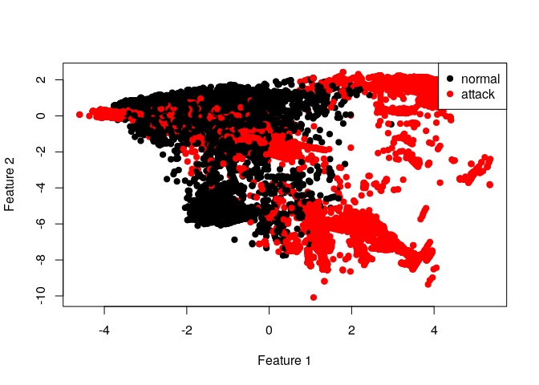

```r
#pca
w <- prcomp(a[,-ncol(a)], retx = TRUE, center = FALSE)
f <- w$x
#rv <- cumsum(w$sdev^2) / sum(w$sdev^2)
#plot(rv,type="l",xlab="number of features",ylab="ratio of retained variance to total variance")
f <- as.data.frame(f)
f <- f[,1:4]
f$label <- a$Lb
a <- f

#apply on test set
g <- as.matrix(b[,-ncol(b)]) %*% (w$rotation)
g <- g[,1:4]
g <- as.data.frame(g)
g$label <- b$Lb
b <- g

png(filename="pca.png")
plot(f[,1],f[,2],col=(f$label+1),pch=19,xlab = "Feature 1",ylab = "Feature 2")
legend("topright",legend = c("normal","attack"), col=1:2, pch = 19)
invisible(dev.off())

plot(f[,1],f[,2],col=(f$label+1),pch=19,xlab = "Feature 1",ylab = "Feature 2")
legend("topright",legend = c("normal","attack"), col=1:2, pch = 19)
```

```r
#Visualize a scatterplot with the first 3 features.
#scatterplot using the first 3 principal components
#if (!require("rgl")) install.packages("rgl")
#library("rgl")
#plot3d(f[,1],f[,2],f[,3],col=(f$label+1),pch=19,xlab = "Feature 1",ylab = "Feature 2")
#legend3d("topright",legend = c("normal","attack"), col=1:2, pch = 19)
```

## Relative density one-class classifier (RDOCC)

We implement a scalable version of the relative density one-class classifier to avoid memory overload when computing distance matrices. The implementation divides the work into manageable blocks.

```r
rdocc_scalable <- function(xtrn, xq, k = 1, h = 1 , fracrej = 0.05, verbose = TRUE){
  #labeled training set xtrn should contain inliers only
  #labeled query points xq (test set)
  #method computes the following difference: ...
  #Parzen density using all training objects - average Parzen density of k nearest neighbors.
  #k is a vector of number of neighbors to try out.
  #h is the standard deviation of the Gaussian kernel.
  #fracrej is the fraction of training objects to reject.

  if(!require("rdist")) install.packages("rdist")
  library("rdist")

  tmp <- xtrn
  colnames(tmp) <- NULL
  trainDataMatrix <- as.matrix(tmp[,-ncol(tmp)])
  #ensure outliers of training set are not used
  Ltrn <- xtrn[,ncol(xtrn)]
  trainDataMatrix <- trainDataMatrix[Ltrn==0,,drop=FALSE] #inliers

  #compute scores using training set:
  #use all training objects to estimate density at training object locations
  Ptrn <- numeric(0)
  colnames(xtrn) <- NULL

  #break into blocks to make scalable
  n <- dim(trainDataMatrix)[1]
  kmax <- max(k)

  Q <- array(0,dim=c(1000,dim(trainDataMatrix)[2],ceiling(n/1000)))
  flag <- 0
  for (i in 1:ceiling(n/1000)){
    tmp <- trainDataMatrix[(1000*(i-1)+1):min(1000*i,n),,drop=FALSE]
    if(dim(tmp)[1] < 1000) {
      pad <- rbind(tmp,matrix(0,nrow=1000-dim(tmp)[1],ncol=dim(trainDataMatrix)[2]))
      Q[,,i] <- pad
      flag <- 1
      realsize <- dim(tmp)[1]
    }
    else Q[,,i] <- tmp
  }

  wideP <- numeric(0)
  corrected_order <- matrix(NA,nrow=1000*ceiling(n/1000),ncol=kmax*ceiling(n/1000))
  dist <- matrix(NA,nrow=1000*ceiling(n/1000),ncol=kmax*ceiling(n/1000))
  K <- matrix(0,nrow=1000*ceiling(n/1000),ncol=ceiling(n/1000))
  for (i in 1:(ceiling(n/1000))){
    if(verbose) print(paste("training: batch...",ceiling(n/1000)-i))
    for (j in 1:(ceiling(n/1000))){
      block <- cdist(Q[,,i],Q[,,j],metric="euclidean")
      gblock <- 1/(h*sqrt(2*pi))*exp(-0.5*(block/h)^2)
      if (j == ceiling(n/1000) & flag == 1) {
        s <- apply(gblock[,1:realsize],1,sum)
        #for knn part
        o <- t(apply(block[,1:realsize],1,order,decreasing=FALSE))
        sorted <- t(apply(block[,1:realsize],1,sort,decreasing=FALSE))
        mn <- min(kmax,realsize)
        corrected_order[(1000*(i-1)+1):(1000*i),(1+((j-1)*kmax)):(mn+((j-1)*kmax))] <- o[,1:mn,drop=FALSE] + (1000*(j-1))
        dist[(1000*(i-1)+1):(1000*i),(1+((j-1)*kmax)):(mn+((j-1)*kmax))] <- sorted[,1:mn,drop=FALSE]
      }
      else {
        s <- apply(gblock,1,sum) #reduce block to column
        #for knn part
        o <- t(apply(block,1,order,decreasing=FALSE))
        sorted <- t(apply(block,1,sort,decreasing=FALSE))
        corrected_order[(1000*(i-1)+1):(1000*i),(1+((j-1)*kmax)):(kmax+((j-1)*kmax))] <- o[,1:kmax,drop=FALSE] + (1000*(j-1))
        dist[(1000*(i-1)+1):(1000*i),(1+((j-1)*kmax)):(kmax+((j-1)*kmax))] <- sorted[,1:kmax,drop=FALSE]
      }
      K[(1000*(i-1)+1):(1000*i),j] <- s  #fill column with the sum
    }
  }
  A <- apply(K,1,sum)
  A <- A[1:dim(trainDataMatrix)[1]]
  A <- A/dim(trainDataMatrix)[1] #ignore the padded zeros
  Ptrn <- h*sqrt(2*pi) * A  #prob. of inlier in [0,1]
  localP <- Ptrn

  thr <- list()
  for (z in seq_along(k)){
    if (dim(dist)[2]==1) {
      O <- matrix(1,nrow=nrow(dist),ncol=1)
    }
    else {
      O <- t(apply(dist,1,order,decreasing=FALSE))[,1:k[z],drop=FALSE]
    }
    nn <- matrix(NA,nrow=dim(O)[1],ncol=k[z])
    for (i in 1:dim(O)[1]){
      nn[i,] <- corrected_order[i,O[i,],drop=FALSE]
    }
    nn <- nn[1:dim(trainDataMatrix)[1],,drop=FALSE] #trim
    Ptst <- matrix(A[nn],nrow=dim(nn)[1],byrow = FALSE)
    Ptst <- h*sqrt(2*pi) * Ptst  #prob. of inlier in [0,1]
    wideP <- apply(Ptst,1,mean)

    relDist <- localP - wideP

    # compute threshold equivalent to fracrej
    nf <- length(relDist)
    relDistSorted <- sort(relDist,decreasing = TRUE)
    nobj_acc <- floor((1-fracrej)*nf)
    if (nobj_acc==0) {
      thr[[z]] <- Inf
    } else if (nobj_acc==nf) {
      thr[[z]] <- -Inf
    } else thr[[z]] <- relDistSorted[nobj_acc]
  }

  #Compute score using query points
  Pq <- numeric(0)
  colnames(xq) <- NULL
  testDataMatrix <- as.matrix(xq[,-ncol(xq)])

  #break into blocks to make scalable
  ntst <- dim(testDataMatrix)[1]
  ntrn <- dim(trainDataMatrix)[1]

  Qtst <- array(0,dim=c(1000,dim(testDataMatrix)[2],ceiling(ntst/1000)))
  for (i in 1:ceiling(ntst/1000)){
    tmp <- testDataMatrix[(1000*(i-1)+1):min(1000*i,ntst),,drop=FALSE]
    if(dim(tmp)[1] < 1000) {
      pad <- rbind(tmp,matrix(0,nrow=1000-dim(tmp)[1],ncol=dim(testDataMatrix)[2]))
      Qtst[,,i] <- pad
    }
    else Qtst[,,i] <- tmp
  }

  Qtrn <- array(0,dim=c(1000,dim(trainDataMatrix)[2],ceiling(ntrn/1000)))
  flag <- 0
  for (i in 1:ceiling(ntrn/1000)){
    tmp <- trainDataMatrix[(1000*(i-1)+1):min(1000*i,ntrn),,drop=FALSE]
    if(dim(tmp)[1] < 1000) {
      pad <- rbind(tmp,matrix(0,nrow=1000-dim(tmp)[1],ncol=dim(trainDataMatrix)[2]))
      Qtrn[,,i] <- pad
      flag <- 1
      realsize <- dim(tmp)[1]
    }
    else Qtrn[,,i] <- tmp
  }

  wideP <- numeric(0)
  corrected_order <- matrix(NA,nrow=1000*ceiling(ntst/1000),ncol=kmax*ceiling(ntrn/1000))
  dist <- matrix(NA,nrow=1000*ceiling(ntst/1000),ncol=kmax*ceiling(ntrn/1000))
  K <- matrix(0,nrow=1000*ceiling(ntst/1000),ncol=ceiling(ntrn/1000))
  for (i in 1:(ceiling(ntst/1000))){
    if(verbose) print(paste("testing: batch...:",ceiling(ntst/1000)-i))
    for (j in 1:(ceiling(ntrn/1000))){
      block <- cdist(Qtst[,,i],Qtrn[,,j],metric="euclidean")
      gblock <- 1/(h*sqrt(2*pi))*exp(-0.5*(block/h)^2)
      if (j == ceiling(ntrn/1000) & flag == 1) {
        s <- apply(gblock[,1:realsize],1,sum)
        #for knn part
        o <- t(apply(block[,1:realsize],1,order,decreasing=FALSE))
        sorted <- t(apply(block[,1:realsize],1,sort,decreasing=FALSE))
        mn <- min(kmax,realsize)
        corrected_order[(1000*(i-1)+1):(1000*i),(1+((j-1)*kmax)):(mn+((j-1)*kmax))] <- o[,1:mn,drop=FALSE] + (1000*(j-1))
        dist[(1000*(i-1)+1):(1000*i),(1+((j-1)*kmax)):(mn+((j-1)*kmax))] <- sorted[,1:mn,drop=FALSE]
        }
      else {
        s <- apply(gblock,1,sum) #reduce block to column
        #for knn part
          o <- t(apply(block,1,order,decreasing=FALSE))
        sorted <- t(apply(block,1,sort,decreasing=FALSE))
        corrected_order[(1000*(i-1)+1):(1000*i),(1+((j-1)*kmax)):(kmax+((j-1)*kmax))] <- o[,1:kmax,drop=FALSE] + (1000*(j-1))
        dist[(1000*(i-1)+1):(1000*i),(1+((j-1)*kmax)):(kmax+((j-1)*kmax))] <- sorted[,1:kmax,drop=FALSE]
      }
      K[(1000*(i-1)+1):(1000*i),j] <- s  #fill column with the sum
    }
  }
  B <- apply(K,1,sum)
  B <- B[1:ntst]
  B <- B/ntrn #ignore the padded zeros
  Pq <- h*sqrt(2*pi) * B  #prob. of inlier in [0,1]
  localP <- Pq

  l <- list()
  for (z in seq_along(k)){
    if (dim(dist)[2]==1) {
      O <- matrix(1,nrow=nrow(dist),ncol=1)
    }
    else {
      O <- t(apply(dist,1,order,decreasing=FALSE))[,1:k[z],drop=FALSE]
    }
    nn <- matrix(NA,nrow=dim(O)[1],ncol=k[z])
    for (i in 1:dim(O)[1]){
      nn[i,] <- corrected_order[i,O[i,],drop=FALSE]
    }
    nn <- nn[1:ntst,,drop=FALSE]
    Ptst <- matrix(A[nn],nrow=dim(nn)[1],byrow=FALSE) #A not B
    Ptst <- h*sqrt(2*pi) * Ptst  #prob. of inlier in [0,1]
    wideP <- apply(Ptst,1,mean)

    f <- localP-wideP

    #Label test set
    Ltst <- rep(0,nrow(xq))
    Ltst[f < thr[[z]]] <- 1 #assign as outlier
    l[[z]] <- Ltst #return list to be consistent with other classifiers
  }
  return(l)
}
```

### Hyperparameter tuning

We set up a function for tuning the hyperparameters of the relative density one-class classifier. The criterion used is balanced accuracy.

```r
tune_rdc <- function(a_train,a_val,fracrej,k,h,verbose=TRUE){
  #a_train: labeled training set as data frame (0=inlier, 1=outlier)
  #a_val: labeled validation set as data frame
  #fracrej: range of valuea for reject fraction in [0,1]
  #k: range of values for number of neighbors k
  #h: range of values for kernel parameter h

  err <- array(NA,dim=c(length(fracrej),length(h),length(k)))

  Yl <- a_train[a_train[,ncol(a_train)]==0,]
  for (j in seq_along(fracrej)){
    if (verbose) print(paste("counter:...",length(fracrej)-j))
    for (l in seq_along(h)){
      out <- rdocc_scalable(as.matrix(Yl), as.matrix(a_val), h=h[l], k=k,
                            fracrej = fracrej[j], verbose=FALSE)
      for (m in seq_along(k)){
        pred <- out[[m]]

        FP <- sum(pred==1 & a_val[,ncol(a_val)]==0)
        TN <- sum(pred==0 & a_val[,ncol(a_val)]==0)
        FN <- sum(pred==0 & a_val[,ncol(a_val)]==1)
        TP <- sum(pred==1 & a_val[,ncol(a_val)]==1)

        error <- (FP/(FP+TN)) + (FN/(FN+TP)) #= FPR + FNR
        error = error/2
        err[j,l,m] <- error
      }
    }
  }

  ind_opt <- which(err==min(err), arr.ind = TRUE)
  if (is.array(ind_opt)){
    fracrej_opt <- fracrej[ind_opt[1,1]]
    h_opt <- h[ind_opt[1,2]]
    k_opt <- k[ind_opt[1,3]]
  }
  else {
    fracrej_opt <- fracrej[ind_opt[1]]
    h_opt <- h[ind_opt[2]]
    k_opt <- k[ind_opt[3]]
  }
  l = list(fracrej_opt=fracrej_opt,k_opt=k_opt,h_opt=h_opt)
  return(l)
}
```

Starting from the training set, we then create a smaller training set and a validation set for tuning the hyperparameters by grid-search over a selected range of values.

```r
#optimize hyperparameters
a0 <- a[a$label==0,]
a1 <- a[a$label==1,]
ind0 <- sample(c(1:dim(a0)[1]),size=min(1000,dim(a0)[1]),replace=FALSE)
ind1 <- sample(c(1:dim(a1)[1]),size=min(1000,dim(a1)[1]),replace=FALSE)
a_val <- rbind(a0[ind0[1:min(500,floor(length(ind0)/2))],],
               a1[ind1[1:min(500,floor(length(ind1)/2))],])
a_train <- rbind(a0[ind0[(min(500,floor(length(ind0)/2))+1):min(1000,length(ind0))],],
                         a1[ind1[(min(500,floor(length(ind1)/2))+1):min(1000,length(ind1))],])

k <- seq(1,min(sum(a_train[,ncol(a_train)]==0),20),by=2)
fracrej <- seq(0.01,0.3,length.out = 10)
h <- seq(0.01,10,length.out = 10)

l <- tune_rdc(a_train,a_val,fracrej,k,h,verbose=FALSE)
fracrej_opt <- l$fracrej_opt
k_opt <- l$k_opt
h_opt <- l$h_opt
```

### Test set performance

Call the classifier on the test set and show the confusion matrix.

```r
#call RDC
Yl <- a[a$label==0,]
out <- rdocc_scalable(as.matrix(Yl), as.matrix(b), h=h_opt, k=k_opt,
                      fracrej = fracrej_opt, verbose=FALSE)
pred <- out[[1]]
cf <- confusionMatrix(factor(pred,levels=c(0,1)),
                      factor(b[,ncol(b)],levels=c(0,1)), positive="1")
print(cf)
```

```
## Confusion Matrix and Statistics
##
##           Reference
## Prediction    0    1
##          0 9402 4611
##          1  309 8222
##
##                Accuracy : 0.7818
##                  95% CI : (0.7763, 0.7871)
##     No Information Rate : 0.5692
##     P-Value [Acc > NIR] : < 2.2e-16
##
##                   Kappa : 0.5777
##
##  Mcnemar's Test P-Value : < 2.2e-16
##
##             Sensitivity : 0.6407
##             Specificity : 0.9682
##          Pos Pred Value : 0.9638
##          Neg Pred Value : 0.6709
##              Prevalence : 0.5692
##          Detection Rate : 0.3647
##    Detection Prevalence : 0.3784
##       Balanced Accuracy : 0.8044
##
##        'Positive' Class : 1
##
```

### ROC/AUC

We write a function for computing the area under the ROC curve by summing up the areas of the trapezoids that make up the curve.

```r
auc <- function(x,y){
  #computes area under ROC curve by summing areas of trapezoids
  dx <- diff(x)
  base1 <- y[1:(length(y)-1)] #base 1 of trapezium
  base2 <- y[2:length(y)]
  trapezium_areas <- (base1+base2)*dx/2
  auc <- sum(trapezium_areas)
  return(auc)
}
```

```r
#roc curve: vary fracrej parameter and test performance on test set
R <- c(seq(1,0.1,length.out = 5),seq(0.09,0,length.out=5))
error_inliers <- error_outliers <- numeric(0)
for (i in seq_along(R)){
  l <- rdocc_scalable(as.matrix(Yl), as.matrix(b), h=h_opt, k=k_opt,
                      fracrej = R[i],verbose=FALSE)
  L <- l[[1]]
  error_outliers[i] <- sum(L==0 & b[,ncol(b)]==1)
  error_inliers[i] <- sum(L==1 & b[,ncol(b)]==0)
}

y_rdc <- 1 - (error_inliers / sum(b[,ncol(b)]==0)) #frac targets accepted
x_rdc <- (error_outliers / sum(b[,ncol(b)]==1)) #frac outliers accepted
auc_rdc <- auc(x_rdc,y_rdc)
```

## Median one-class classifier (MOCC)

We implement a scalable version of the median one-class classifier (MOCC) to avoid memory overload when computing distance matrices. The implementation divides the work into manageable blocks.

```r
mocc_scalable <- function(xtrn, xq, k = 1, fracrej = 0.05, verbose = TRUE){
  #labeled training set xtrn should contain inliers only
  #labeled query points xq (test set)
  #method computes the distance from a test object to the median of its k-nearest neighbors.
  #k is a vector of number of neighbors to try out.
  #fracrej is the fraction of training objects to reject.

  if(!require("rdist")) install.packages("rdist")
  library("rdist")

  tmp <- xtrn
  colnames(tmp) <- NULL
  trainDataMatrix <- as.matrix(tmp[,-ncol(tmp)])
  #ensure outliers of training set are not used
  Ltrn <- xtrn[,ncol(xtrn)]
  trainDataMatrix <- trainDataMatrix[Ltrn==0,,drop=FALSE] #inliers

  colnames(xtrn) <- NULL

  #break into blocks to make scalable
  n <- dim(trainDataMatrix)[1]
  kmax <- max(k)

  Q <- array(0,dim=c(1000,dim(trainDataMatrix)[2],ceiling(n/1000)))
  flag <- 0
  for (i in 1:ceiling(n/1000)){
    tmp <- trainDataMatrix[(1000*(i-1)+1):min(1000*i,n),,drop=FALSE]
    if(dim(tmp)[1] < 1000) {
      pad <- rbind(tmp,matrix(0,nrow=1000-dim(tmp)[1],ncol=dim(trainDataMatrix)[2]))
      Q[,,i] <- pad
      flag <- 1
      realsize <- dim(tmp)[1]
    }
    else Q[,,i] <- tmp
  }

  wideP <- numeric(0)
  corrected_order <- matrix(NA,nrow=1000*ceiling(n/1000),ncol=kmax*ceiling(n/1000))
  dist <- matrix(NA,nrow=1000*ceiling(n/1000),ncol=kmax*ceiling(n/1000))
  for (i in 1:(ceiling(n/1000))){
    if(verbose) print(paste("training: batch...",ceiling(n/1000)-i))
    for (j in 1:(ceiling(n/1000))){
      block <- cdist(Q[,,i],Q[,,j],metric="euclidean")
      if (j == ceiling(n/1000) & flag == 1) {
        #for knn part
        o <- t(apply(block[,1:realsize],1,order,decreasing=FALSE))
        sorted <- t(apply(block[,1:realsize],1,sort,decreasing=FALSE))
        mn <- min(kmax,realsize)
        corrected_order[(1000*(i-1)+1):(1000*i),(1+((j-1)*kmax)):(mn+((j-1)*kmax))] <- o[,1:mn,drop=FALSE] + (1000*(j-1))
        dist[(1000*(i-1)+1):(1000*i),(1+((j-1)*kmax)):(mn+((j-1)*kmax))] <- sorted[,1:mn,drop=FALSE]
      }
      else {
        #for knn part
        o <- t(apply(block,1,order,decreasing=FALSE))
        sorted <- t(apply(block,1,sort,decreasing=FALSE))
        corrected_order[(1000*(i-1)+1):(1000*i),(1+((j-1)*kmax)):(kmax+((j-1)*kmax))] <- o[,1:kmax,drop=FALSE] + (1000*(j-1))
        dist[(1000*(i-1)+1):(1000*i),(1+((j-1)*kmax)):(kmax+((j-1)*kmax))] <- sorted[,1:kmax,drop=FALSE]
      }
    }
  }

  thr <- list()
  for (z in seq_along(k)){
    if (dim(dist)[2]==1) {
      O <- matrix(1,nrow=nrow(dist),ncol=1)
    }
    else {
      O <- t(apply(dist,1,order,decreasing=FALSE))[,1:k[z],drop=FALSE]
    }
    nn <- matrix(NA,nrow=dim(O)[1],ncol=k[z])
    for (i in 1:dim(O)[1]){
      nn[i,] <- corrected_order[i,O[i,],drop=FALSE]
    }
    nn <- nn[1:dim(trainDataMatrix)[1],,drop=FALSE] #trim

    relDist <- c()
    for (i in 1:nrow(nn)){
      xmed <- apply(trainDataMatrix[nn[i,], ,drop=FALSE],2,median) #compute median feature values
      relDist[i] <- sqrt(sum((trainDataMatrix[i,] - xmed)^2))
    }
    # compute threshold equivalent to fracrej
    nf <- length(relDist)
    relDistSorted <- sort(relDist,decreasing = FALSE)
    nobj_acc <- floor((1-fracrej)*nf)
    if (nobj_acc==0) {
      thr[[z]] <- -Inf
    } else if (nobj_acc==nf) {
      thr[[z]] <- Inf
    } else thr[[z]] <- relDistSorted[nobj_acc]
  }

  #Compute score using query points
  colnames(xq) <- NULL
  testDataMatrix <- as.matrix(xq[,-ncol(xq)])

  #break into blocks to make scalable
  ntst <- dim(testDataMatrix)[1]
  ntrn <- dim(trainDataMatrix)[1]

  Qtst <- array(0,dim=c(1000,dim(testDataMatrix)[2],ceiling(ntst/1000)))
  for (i in 1:ceiling(ntst/1000)){
    tmp <- testDataMatrix[(1000*(i-1)+1):min(1000*i,ntst),,drop=FALSE]
    if(dim(tmp)[1] < 1000) {
      pad <- rbind(tmp,matrix(0,nrow=1000-dim(tmp)[1],ncol=dim(testDataMatrix)[2]))
      Qtst[,,i] <- pad
    }
    else Qtst[,,i] <- tmp
  }

  Qtrn <- array(0,dim=c(1000,dim(trainDataMatrix)[2],ceiling(ntrn/1000)))
  flag <- 0
  for (i in 1:ceiling(ntrn/1000)){
    tmp <- trainDataMatrix[(1000*(i-1)+1):min(1000*i,ntrn),,drop=FALSE]
    if(dim(tmp)[1] < 1000) {
      pad <- rbind(tmp,matrix(0,nrow=1000-dim(tmp)[1],ncol=dim(trainDataMatrix)[2]))
      Qtrn[,,i] <- pad
      flag <- 1
      realsize <- dim(tmp)[1]
    }
    else Qtrn[,,i] <- tmp
  }

  corrected_order <- matrix(NA,nrow=1000*ceiling(ntst/1000),ncol=kmax*ceiling(ntrn/1000))
  dist <- matrix(NA,nrow=1000*ceiling(ntst/1000),ncol=kmax*ceiling(ntrn/1000))
  for (i in 1:(ceiling(ntst/1000))){
    if(verbose) print(paste("testing: batch...:",ceiling(ntst/1000)-i))
    for (j in 1:(ceiling(ntrn/1000))){
      block <- cdist(Qtst[,,i],Qtrn[,,j],metric="euclidean")
      if (j == ceiling(ntrn/1000) & flag == 1) {
        #for knn part
        o <- t(apply(block[,1:realsize],1,order,decreasing=FALSE))
        sorted <- t(apply(block[,1:realsize],1,sort,decreasing=FALSE))
        mn <- min(kmax,realsize)
        corrected_order[(1000*(i-1)+1):(1000*i),(1+((j-1)*kmax)):(mn+((j-1)*kmax))] <- o[,1:mn,drop=FALSE] + (1000*(j-1))
        dist[(1000*(i-1)+1):(1000*i),(1+((j-1)*kmax)):(mn+((j-1)*kmax))] <- sorted[,1:mn,drop=FALSE]
      }
      else {
        #for knn part
        o <- t(apply(block,1,order,decreasing=FALSE))
        sorted <- t(apply(block,1,sort,decreasing=FALSE))
        corrected_order[(1000*(i-1)+1):(1000*i),(1+((j-1)*kmax)):(kmax+((j-1)*kmax))] <- o[,1:kmax,drop=FALSE] + (1000*(j-1))
        dist[(1000*(i-1)+1):(1000*i),(1+((j-1)*kmax)):(kmax+((j-1)*kmax))] <- sorted[,1:kmax,drop=FALSE]
      }
    }
  }

  l <- list()
  for (z in seq_along(k)){
    if (dim(dist)[2]==1) {
      O <- matrix(1,nrow=nrow(dist),ncol=1)
    }
    else {
      O <- t(apply(dist,1,order,decreasing=FALSE))[,1:k[z],drop=FALSE]
    }
    nn <- matrix(NA,nrow=dim(O)[1],ncol=k[z])
    for (i in 1:dim(O)[1]){
      nn[i,] <- corrected_order[i,O[i,],drop=FALSE]
    }
    nn <- nn[1:ntst,,drop=FALSE]

    f <- c()
    for (i in 1:nrow(nn)){
      xmed <- apply(trainDataMatrix[nn[i,], ,drop=FALSE],2,median) #compute median feature values
      f[i] <- sqrt(sum((testDataMatrix[i,] - xmed)^2))
    }

    #Label test set
    Ltst <- rep(0,nrow(xq))
    Ltst[f > thr[[z]]] <- 1 #assign as outlier
    l[[z]] <- Ltst #return list to be consistent with other classifiers
  }
  return(l)
}
```

### Hyperparameter tuning

We set up a function for tuning the hyperparameters of MOCC. The criterion used is balanced accuracy.

```r
tune_mocc <- function(a_train,a_val,fracrej,k,verbose=TRUE){
  #a_train: labeled training set as data frame (0=inlier, 1=outlier)
  #a_val: labeled validation set as data frame
  #fracrej: range of valuea for reject fraction in [0,1]
  #k: range of values for number of neighbors k

  err <- array(NA,dim=c(length(fracrej),length(k)))

  Yl <- a_train[a_train[,ncol(a_train)]==0,]
  for (j in seq_along(fracrej)){
    if (verbose) print(paste("counter:...",length(fracrej)-j))
    #for (l in seq_along(h)){
      out <- mocc_scalable(as.matrix(Yl), as.matrix(a_val), k=k,
                            fracrej = fracrej[j], verbose=FALSE)
      for (m in seq_along(k)){
        pred <- out[[m]]

        FP <- sum(pred==1 & a_val[,ncol(a_val)]==0)
        TN <- sum(pred==0 & a_val[,ncol(a_val)]==0)
        FN <- sum(pred==0 & a_val[,ncol(a_val)]==1)
        TP <- sum(pred==1 & a_val[,ncol(a_val)]==1)

        error <- (FP/(FP+TN)) + (FN/(FN+TP)) #= FPR + FNR
        error = error/2
        err[j,m] <- error
    #  }
    }
  }

  ind_opt <- which(err==min(err), arr.ind = TRUE)
  if (is.array(ind_opt)){
    fracrej_opt <- fracrej[ind_opt[1,1]]
    k_opt <- k[ind_opt[1,2]]
  }
  else {
    fracrej_opt <- fracrej[ind_opt[1]]
    k_opt <- k[ind_opt[2]]
  }
  l = list(fracrej_opt=fracrej_opt,k_opt=k_opt)
  return(l)
}
```

Starting from the training set, we then create a smaller training set and a validation set for tuning the hyperparameters by grid-search over a selected range of values.

```r
#optimize hyperparameters
k <- seq(1,min(sum(a_train[,ncol(a_train)]==0),20),by=2)
fracrej <- seq(0.01,0.3,length.out = 10)

l <- tune_mocc(a_train,a_val,fracrej,k,verbose=FALSE)
fracrej_opt <- l$fracrej_opt
k_opt <- l$k_opt
```

### Test set performance

Call the classifier on the test set and show the confusion matrix.

```r
#call RDC
Yl <- a[a$label==0,]
out <- mocc_scalable(as.matrix(Yl), as.matrix(b), k=k_opt,
                      fracrej = fracrej_opt, verbose=FALSE)
pred <- out[[1]]
cf <- confusionMatrix(factor(pred,levels=c(0,1)),
                      factor(b[,ncol(b)],levels=c(0,1)),positive="1")
print(cf)
```

```
## Confusion Matrix and Statistics
##
##           Reference
## Prediction     0     1
##          0  8540  1434
##          1  1171 11399
##
##                Accuracy : 0.8844
##                  95% CI : (0.8802, 0.8886)
##     No Information Rate : 0.5692
##     P-Value [Acc > NIR] : < 2.2e-16
##
##                   Kappa : 0.7652
##
##  Mcnemar's Test P-Value : 2.847e-07
##
##             Sensitivity : 0.8883
##             Specificity : 0.8794
##          Pos Pred Value : 0.9068
##          Neg Pred Value : 0.8562
##              Prevalence : 0.5692
##          Detection Rate : 0.5056
##    Detection Prevalence : 0.5576
##       Balanced Accuracy : 0.8838
##
##        'Positive' Class : 1
##
```

### ROC/AUC

We write a function for computing the area under the ROC curve by summing up the areas of the trapezoids that make up the curve.

```r
auc <- function(x,y){
  #computes area under ROC curve by summing areas of trapezoids
  dx <- diff(x)
  base1 <- y[1:(length(y)-1)] #base 1 of trapezium
  base2 <- y[2:length(y)]
  trapezium_areas <- (base1+base2)*dx/2
  auc <- sum(trapezium_areas)
  return(auc)
}
```

```r
#roc curve: vary fracrej parameter and test performance on test set
R <- c(seq(1,0.1,length.out = 5),seq(0.09,0,length.out=5))
error_inliers <- error_outliers <- numeric(0)
for (i in seq_along(R)){
  l <- mocc_scalable(as.matrix(Yl), as.matrix(b), k=k_opt,
                      fracrej = R[i],verbose=FALSE)
  L <- l[[1]]
  error_outliers[i] <- sum(L==0 & b[,ncol(b)]==1)
  error_inliers[i] <- sum(L==1 & b[,ncol(b)]==0)
}

y_mocc <- 1 - (error_inliers / sum(b[,ncol(b)]==0)) #frac targets accepted
x_mocc <- (error_outliers / sum(b[,ncol(b)]==1)) #frac outliers accepted
auc_mocc <- auc(x_mocc,y_mocc)
```

## Isolation forest

We write a wrapper function around the isolation forest classifier allowing for a reject fraction.

```r
iForest <- function(xtrn, xtst, fracrej, sample_size = 256){
  #isolation forest:
  #xtrn: labeled training set, should contain inliers only
  #xtst: labeled test set can contain inliers and outliers
  #fracrej is the fraction of training objects to reject as outliers.
  #sample_size: number of objects used to build a tree in the forest

  if(!require("solitude")) install.packages("solitude")
  library("solitude")

  isf <- isolationForest$new(sample_size = sample_size)  # initiate
  x <- as.data.frame(xtrn[,-ncol(xtrn)])
  isf$fit(x)
  #isf$scores #anomaly scores
  #scores closer to 1 => outliers
  s <- isf$predict(x) # scores for training set
  ss <- sort(s$anomaly_score, decreasing = TRUE)
  nrej <- ceiling(fracrej * length(ss))
  if (fracrej==1) thr <- -Inf
  else if (fracrej==0) thr <- Inf
  else thr <- ss[nrej]

  y <- as.data.frame(xtst[,-ncol(xtst)])
  s <- isf$predict(y) # scores for test set
  out <- (s$anomaly_score > thr)
  out <- as.numeric(out)
  return(list(out))
}
```

### Hyperparameter tuning

We tune an isolation forest classifier using a wrapper function through which we identify the optimal reject fraction based on the criterion of balanced accuracy.

```r
tune_iforest <- function(a_train,a_val,fracrej,verbose=TRUE){
  #a_train: labeled training set as data frame (0=inlier, 1=outlier)
  #a_val: labeled validation set as data frame
  #fracrej: range of values for reject fraction in [0,1]

  err <- rep(NA,length(fracrej))
  Yl <- a_train[a_train[,ncol(a_train)]==0,]
  x <- as.data.frame(Yl)
  y <- as.data.frame(a_val)
  colnames(y) <- colnames(x)
  for (j in seq_along(fracrej)){
    if (verbose) print(paste("counter:...",length(fracrej)-j))
    out <- iForest(x,y,fracrej=fracrej[j],sample_size = dim(x)[1])
    pred <- out[[1]]

    FP <- sum(pred==1 & a_val[,ncol(a_val)]==0)
    TN <- sum(pred==0 & a_val[,ncol(a_val)]==0)
    FN <- sum(pred==0 & a_val[,ncol(a_val)]==1)
    TP <- sum(pred==1 & a_val[,ncol(a_val)]==1)

    error <- (FP/(FP+TN)) + (FN/(FN+TP)) #= FPR + FNR
    error = error/2
    err[j] <- error
  }

  ind_opt <- which(err==min(err))#, arr.ind = TRUE)
  fracrej_opt <- fracrej[ind_opt[1]]

  l = list(fracrej_opt=fracrej_opt)
  return(l)
}
```

```r
#isolation forest
fracrej <- seq(0.01,0.3,length.out = 10)
suppressMessages(l <- tune_iforest(a_train,a_val,fracrej,verbose=FALSE))
fracrej_opt <- l$fracrej_opt
```

### Test set performance

Call the classifier on the test set and show the confusion matrix.

```r
Yl <- a[a$label==0,]
x <- as.data.frame(Yl)
y <- as.data.frame(b)
colnames(y) <- colnames(x)

out <- suppressMessages(iForest(x,y,fracrej= fracrej_opt, sample_size = dim(x)[1]))
pred <- out[[1]]
cf <- confusionMatrix(factor(pred,levels=c(0,1)),
                      factor(y[,ncol(y)],levels=c(0,1)),positive="1")
print(cf)
```

```
## Confusion Matrix and Statistics
##
##           Reference
## Prediction    0    1
##          0 9072 4267
##          1  639 8566
##
##                Accuracy : 0.7824
##                  95% CI : (0.7769, 0.7878)
##     No Information Rate : 0.5692
##     P-Value [Acc > NIR] : < 2.2e-16
##
##                   Kappa : 0.5755
##
##  Mcnemar's Test P-Value : < 2.2e-16
##
##             Sensitivity : 0.6675
##             Specificity : 0.9342
##          Pos Pred Value : 0.9306
##          Neg Pred Value : 0.6801
##              Prevalence : 0.5692
##          Detection Rate : 0.3800
##    Detection Prevalence : 0.4083
##       Balanced Accuracy : 0.8008
##
##        'Positive' Class : 1
##
```

### ROC/AUC

Compute the ROC curve and AUC value.

```r
#roc curve: vary fracrej parameter and test performance on test set
R <- c(seq(1,0.1,length.out = 5),seq(0.09,0,length.out=5))
error_inliers <- error_outliers <- numeric(0)
for (i in seq_along(R)){
  l <- suppressMessages(iForest(x,y,fracrej=R[i], sample_size = dim(x)[1]))
  L <- l[[1]]
  error_outliers[i] <- sum(L==0 & y[,ncol(y)]==1)
  error_inliers[i] <- sum(L==1 & y[,ncol(y)]==0)
}

y_rf <- 1 - (error_inliers / sum(y[,ncol(y)]==0)) #frac targets accepted
x_rf <- (error_outliers / sum(y[,ncol(y)]==1)) #frac outliers accepted accepted
auc_rf <- auc(x_rf,y_rf)
```

## Support vector machine

### Hyperparameter tuning

We tune a support vector machine based on the criterion of balanced accuracy.

```r
tune_svm <- function(a_train,a_val,nu,gamma,verbose=TRUE){
  #a_train: labeled training set as data frame (0=inlier, 1=outlier)
  #a_val: labeled validation set as data frame
  #nu: range of values in ]0,1[
  #gamma: range of values for gamma

  err <- matrix(NA,nrow=length(nu),ncol=length(gamma))
  Yl <- a_train[a_train[,ncol(a_train)]==0,]
  x <- as.data.frame(Yl)
  y <- as.data.frame(a_val)
  colnames(y) <- colnames(x)
  for (j in seq_along(nu)){
    if(verbose) print(paste("counter:...",length(nu)-j))
    for (l in seq_along(gamma)){
      model <- svm(x = x[,-ncol(x)], y = x[,ncol(x)], type="one-classification",
                   kernel="radial",nu=nu[j],gamma = gamma[l])
      pred <- predict(model, y[,-ncol(y)])
      pred <- as.numeric(!pred)
      #err[i,j,l] <- sum(pred!=y[,ncol(y)])

      FP <- sum(pred==1 & a_val[,ncol(a_val)]==0)
      TN <- sum(pred==0 & a_val[,ncol(a_val)]==0)
      FN <- sum(pred==0 & a_val[,ncol(a_val)]==1)
      TP <- sum(pred==1 & a_val[,ncol(a_val)]==1)

      error <- (FP/(FP+TN)) + (FN/(FN+TP)) #= FPR + FNR
      error = error/2
      err[j,l] <- error
      }
    }

  ind_opt <- which(err==min(err), arr.ind = TRUE)
  if (is.array(ind_opt)){
    nu_opt <- nu[ind_opt[1,1]]
    gamma_opt <- gamma[ind_opt[1,2]]
  }
  else {
    nu_opt <- nu[ind_opt[1]]
    gamma_opt <- gamma[ind_opt[2]]
  }

  l = list(nu_opt=nu_opt,gamma_opt=gamma_opt)
  return(l)
}
```

```r
#optimize hyperparameters
nu <- seq(0.01,0.99,length.out = 40)
gamma <- seq(0.01,0.99,length.out = 40)

l <- tune_svm(a_train,a_val,nu,gamma,verbose=FALSE)
nu_opt <- l$nu_opt
gamma_opt <- l$gamma_opt
```

### Test set performance

Call the classifier on the test set and show the confusion matrix.

```r
Yl <- a[a$label==0,]
x <- as.data.frame(Yl)
y <- as.data.frame(b)
colnames(y) <- colnames(x)

model <- svm(x = x[,-ncol(x)], y = x[,ncol(x)], type="one-classification", kernel="radial",
             nu=nu_opt, gamma = gamma_opt)

#Test the model on test set
pred <- predict(model, y[,-ncol(y)])
cf <- confusionMatrix(factor(as.numeric(!pred),levels=c(0,1)),
                      factor(y[,ncol(y)],levels=c(0,1)), positive="1")
print(cf)
```

```
## Confusion Matrix and Statistics
##
##           Reference
## Prediction    0    1
##          0 9540 5239
##          1  171 7594
##
##                Accuracy : 0.76
##                  95% CI : (0.7544, 0.7656)
##     No Information Rate : 0.5692
##     P-Value [Acc > NIR] : < 2.2e-16
##
##                   Kappa : 0.5399
##
##  Mcnemar's Test P-Value : < 2.2e-16
##
##             Sensitivity : 0.5918
##             Specificity : 0.9824
##          Pos Pred Value : 0.9780
##          Neg Pred Value : 0.6455
##              Prevalence : 0.5692
##          Detection Rate : 0.3369
##    Detection Prevalence : 0.3444
##       Balanced Accuracy : 0.7871
##
##        'Positive' Class : 1
##
```

### ROC/AUC

Compute the ROC curve and AUC value.

```r
#roc
predtest <- predict(model,y[,-ncol(y)],decision.values=TRUE)
lp <- attributes(predtest)$decision.values
R <- seq(max(lp),min(lp),length.out=10)
error_inliers <- error_outliers <- numeric(0)
for (i in seq_along(R)){
  L <- as.numeric(lp < R[i])
  error_outliers[i] <- sum(L==0 & y[,ncol(y)]==1)
  error_inliers[i] <- sum(L==1 & y[,ncol(y)]==0)
}
y_svm <- 1 - (error_inliers / sum(y[,ncol(y)]==0)) #frac targets accepted
x_svm <- (error_outliers / sum(y[,ncol(y)]==1)) #frac outliers accepted
auc_svm <- auc(x_svm,y_svm)
```

## Local outlier factor

We write a wrapper function around the local outlier factor classifier allowing for a reject fraction. Normally this classifier is for an unsupervised setting, so we compute the anomaly score of one test object at a time (given the training set and the particular test object). In other words, we have extended the classifier to return labels for new test objects.

```r
lof_wrapper <- function(xtrn, xtst, k = 5, fracrej = 0.01, cores=2){
  #local outlier factor:
  #xtrn: labeled training set, should contain inliers only
  #xtst: labeled test set can contain both inliers and outliers
  #k: number of neighbors to consider
  #fracrej: the fraction of training objects to reject as outliers.
  #cores: number of CPUs to run in parallel

  if(!require("Rlof")) install.packages("Rlof")
  library("Rlof")

  x <- xtrn[,-ncol(xtrn)]
  scores_training <- lof(x,k,cores)
  if (length(k)==1) scores_training <- as.matrix(scores_training)

  out <- list()
  for (z in seq_along(k)){
    ss <- sort(scores_training[,z], decreasing = TRUE)
    nrej <- ceiling(fracrej * length(ss))
    if (fracrej==1) thr <- -Inf
    else if (fracrej==0) thr <- Inf
    else thr <- ss[nrej]

    tmp <- rep(0,dim(xtst)[1])
    for (i in 1:dim(xtst)[1]){
      score <- lof(rbind(x,xtst[i,-ncol(xtst)]),k,cores)
      if(length(k)==1) score <- as.matrix(score)
      tmp[i] <- as.numeric(score[nrow(score),z] > thr)
    }
    out[[z]] <- tmp
  }
  return(out)
}
```

### Hyperparameter tuning

We tune a local outlier factor (LOF) classifier based on the criterion of balanced accuracy.

```r
tune_lof <- function(a_train,a_val,fracrej,k,verbose=TRUE){
  #a_train: labeled training set as data frame (0=inlier, 1=outlier)
  #a_val: labeled validation set as data frame
  #fracrej: range of values for reject fraction in [0,1]
  #k: range of values for number of neighbors

  err <- matrix(NA,nrow=length(fracrej),ncol=length(k))
  Yl <- a_train[a_train[,ncol(a_train)]==0,]
  x <- as.data.frame(Yl)
  y <- as.data.frame(a_val)
  colnames(y) <- colnames(x)
  for (j in seq_along(fracrej)){
    if(verbose) print(paste("counter:...",length(fracrej)-j))
      out <- lof_wrapper(x, y, k = k, fracrej = fracrej[j], cores=1)
      for (l in seq_along(k)){
        pred <- out[[l]]

        FP <- sum(pred==1 & a_val[,ncol(a_val)]==0)
        TN <- sum(pred==0 & a_val[,ncol(a_val)]==0)
        FN <- sum(pred==0 & a_val[,ncol(a_val)]==1)
        TP <- sum(pred==1 & a_val[,ncol(a_val)]==1)

        error <- (FP/(FP+TN)) + (FN/(FN+TP)) #= FPR + FNR
        error = error/2
        err[j,l] <- error
    }
  }

  ind_opt <- which(err==min(err), arr.ind = TRUE)
  if (is.array(ind_opt)){
    fracrej_opt <- fracrej[ind_opt[1,1]]
    k_opt <- k[ind_opt[1,2]]
  }
  else {
    fracrej_opt <- fracrej[ind_opt[1]]
    k_opt <- k[ind_opt[2]]
  }

  l = list(fracrej_opt=fracrej_opt,k_opt=k_opt)
  return(l)
}
```

We use a small training set and validation set when tuning due to the high computational expense of this classifier. We also assume a nearest neighbor hyperparameter of 20 neighbors at most.

```r
a_val <- rbind(a0[ind0[1:min(50,floor(length(ind0)/2))],],
               a1[ind1[1:min(50,floor(length(ind1)/2))],])
a_train <- rbind(a0[ind0[(min(50,floor(length(ind0)/2))+1):min(100,length(ind0))],],
                         a1[ind1[(min(50,floor(length(ind1)/2))+1):min(100,length(ind1))],])

fracrej <- seq(0.01,0.3,length.out = 20)
k <- seq(2,min(20,sum(a_train$label==0)-1),by=3)
l <- tune_lof(a_train,a_val,fracrej,k,verbose=FALSE)
fracrej_opt <- l$fracrej_opt
k_opt <- l$k_opt
```

### Test set performance

Sample a small subset from the test set to assess performance due to the high computational complexity. Call the classifier on this subset and show the confusion matrix.

```r
b0 <- b[b$label==0,]
b1 <- b[b$label==1,]
ind0 <- sample(c(1:dim(b0)[1]),size=min(100,dim(b0)[1]),replace=FALSE)
ind1 <- sample(c(1:dim(b1)[1]),size=min(100,dim(b1)[1]),replace=FALSE)
b_test <- rbind(b0[ind0,],b1[ind1,])

Yl <- a_train[a_train$label==0,]
x <- as.data.frame(Yl)
y <- as.data.frame(b_test)
colnames(y) <- colnames(x)

out <- lof_wrapper(x, y, k = k_opt, fracrej = fracrej_opt, cores=1)
pred <- out[[1]]
cf <- confusionMatrix(factor(pred,levels=c(0,1)),
                      factor(b_test[,ncol(b_test)],levels=c(0,1)),positive="1")
print(cf)
```

```
## Confusion Matrix and Statistics
##
##           Reference
## Prediction  0  1
##          0 79 54
##          1 21 46
##
##                Accuracy : 0.625
##                  95% CI : (0.5539, 0.6923)
##     No Information Rate : 0.5
##     P-Value [Acc > NIR] : 0.0002497
##
##                   Kappa : 0.25
##
##  Mcnemar's Test P-Value : 0.0002199
##
##             Sensitivity : 0.4600
##             Specificity : 0.7900
##          Pos Pred Value : 0.6866
##          Neg Pred Value : 0.5940
##              Prevalence : 0.5000
##          Detection Rate : 0.2300
##    Detection Prevalence : 0.3350
##       Balanced Accuracy : 0.6250
##
##        'Positive' Class : 1
##
```

### ROC/AUC

Compute the ROC curve and AUC value.

```r
#roc curve: vary fracrej parameter and test performance on test set
R <- c(seq(1,0.1,length.out = 10),seq(0.09,0,length.out=10))
error_inliers <- error_outliers <- numeric(0)
for (i in seq_along(R)){
  l <- lof_wrapper(x, y, k = k_opt, fracrej = R[i], cores=1)
  L <- l[[1]]
  error_outliers[i] <- sum(L==0 & y[,ncol(y)]==1)
  error_inliers[i] <- sum(L==1 & y[,ncol(y)]==0)
}

y_lof<- 1 - (error_inliers / sum(y[,ncol(y)]==0)) #frac targets accepted
x_lof <- (error_outliers / sum(y[,ncol(y)]==1)) #frac outliers accepted
auc_lof <- auc(x_lof,y_lof)
```

## Compare ROC curves

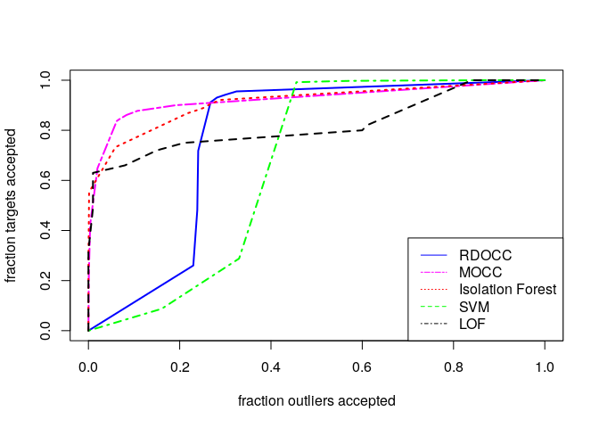

```r
png(filename="roc_normal_attack.png")
plot(x_rdc,y_rdc,col="blue",type="l",lwd=2,
     xlab="fraction outliers accepted",
     ylab="fraction targets accepted")
lines(x_mocc,y_mocc,col="magenta",type="l",lty = "twodash", lwd=2)
lines(x_rf,y_rf,col="red",type="l",lty = "dotted", lwd=2)
lines(x_svm,y_svm,col="green",type="l", lty = "dotdash", lwd=2)
lines(x_lof,y_lof,col="black",type="l",lty = "dashed", lwd=2)
legend("bottomright",legend=c("RDOCC","MOCC","Isolation Forest","SVM","LOF"),
       lty=c("solid","twodash","dotted","dashed","dotdash"),
       col=c("blue","magenta","red","green","black"))
invisible(dev.off())

plot(x_rdc,y_rdc,col="blue",type="l",lwd=2,
     xlab="fraction outliers accepted",
     ylab="fraction targets accepted")
lines(x_mocc,y_mocc,col="magenta",type="l",lty = "twodash", lwd=2)
lines(x_rf,y_rf,col="red",type="l",lty = "dotted", lwd=2)
lines(x_svm,y_svm,col="green",type="l", lty = "dotdash", lwd=2)
lines(x_lof,y_lof,col="black",type="l",lty = "dashed", lwd=2)
legend("bottomright",legend=c("RDOCC","MOCC","Isolation Forest","SVM","LOF"),
       lty=c("solid","twodash","dotted","dashed","dotdash"),
       col=c("blue","magenta","red","green","black"))
```

```r
dfauc <- data.frame(classifier = c("RDOCC","MOCC","Isolation Forest","SVM","LOF"),
                    AUC = c(auc_rdc, auc_mocc, auc_rf, auc_svm, auc_lof))
print(dfauc)
```

```
##         classifier       AUC
## 1            RDOCC 0.7701670
## 2             MOCC 0.9229072
## 3 Isolation Forest 0.9113232
## 4              SVM 0.6625310
## 5              LOF 0.8212500
```

# Multi-class classification

## Class label statistics (training set)

```r
#Multi-class (Normal,Probe,DoS,U2R,R2L) classification

#class indices (training set)
l <- data_trn[,"attack"]
iNormal <- l == "normal"
iProbe <- l %in% c("satan","ipsweep","nmap",
                   "portsweep","mscan","saint")
iDoS <- l %in% c("back","land","neptune","pod","smurf",
                 "teardrop","apache2","udpstorm","processtable","mailbomb")
iU2R <- l %in% c("buffer_overflow","loadmodule","rootkit","perl","sqlattack",
                 "xterm","ps")
iR2L <- l %in% c("guess_passwd","ftp_write","imap","phf","multihop",
                 "warezmaster","warezclient","spy","xlock","xsnoop",
                 "snmpguess","snmpgetattack","httptunnel","sendmail",
                 "named","worm")

A <- data_trn[,-43] #drop $Lb
labels <- rep(NA,dim(A)[1]) #initialize labels column
labels[iNormal] <- 0
labels[iProbe] <- 1
labels[iDoS] <- 2
labels[iU2R] <- 3
labels[iR2L] <- 4
A$label <- labels

df <- as.data.frame(table(A$label))
colnames(df) <- c("Label", "Frequency")
rownames(df) <- c("Normal", "Probe","DoS","U2R","R2L")
print(df)
```

```
##        Label Frequency
## Normal     0     67343
## Probe      1     11656
## DoS        2     45927
## U2R        3        52
## R2L        4       995
```

## Class label statistics (test set)

```r
#class indices (test set)
l <- data_tst[,"attack"]
iNormal <- l =="normal"
iProbe <- l %in% c("satan","ipsweep","nmap",
                   "portsweep","mscan","saint")
iDoS <- l %in% c("back","land","neptune","pod","smurf",
                 "teardrop","apache2","udpstorm","processtable","mailbomb")
iU2R <- l %in% c("buffer_overflow","loadmodule","rootkit","perl","sqlattack",
                 "xterm","ps")
iR2L <- l %in% c("guess_passwd","ftp_write","imap","phf","multihop",
                 "warezmaster","warezclient","spy","xlock","xsnoop",
                 "snmpguess","snmpgetattack","httptunnel","sendmail",
                 "named","worm")

B <- data_tst[,-43]
labels <- rep(NA,dim(B)[1]) #initialize labels column
labels[iNormal] <- 0
labels[iProbe] <- 1
labels[iDoS] <- 2
labels[iU2R] <- 3
labels[iR2L] <- 4
B$label <- labels

df <- as.data.frame(table(B$label))
colnames(df) <- c("Label", "Frequency")
rownames(df) <- c("Normal", "Probe","DoS","U2R","R2L")
print(df)
```

```
##        Label Frequency
## Normal     0      9711
## Probe      1      2421
## DoS        2      7458
## U2R        3        67
## R2L        4      2887
```

## One-hot encoding of nominal features

To perform one-hot encoding of features, the training set and test set are first combined since the test set contains additional levels (categories) for some features. Such levels are not apparent in the training set. Once the combined data is encoded, the training set and test test are then re-split.

```r
ta <- A[,-c(42,43)] #remove labels
tb <- B[,-c(42,43)] #remove labels
flg <- dim(ta)[1]
Comb <- rbind(ta,tb)
dmy <- dummyVars(" ~ .", data = Comb)
Comb <- data.frame(predict(dmy, newdata = Comb))
#colnames(Comb)

tA <- Comb[1:flg,]
tA$label <- A$label
tB <- Comb[-c(1:flg),]
tB$label <- B$label

xtrn <- tA
xtst <- tB
```

## Multiple one-class classifiers

We train a one-class relative density one-class classifier in a one-against-all scheme for each of the 5 classes: *normal*, *Probe*, *DoS*, *U2R*, or *R2L*, followed by a majority vote. Ties are broken by assigning to the class with the nearest mean from among the classes that are in tie. In case an object is rejected as outlier by all 5 classifiers, it is assigned to the class with the nearest mean.

## Normalization

We first drop any irrelavant (non-varying) features and normalize the data based on the training set.

```r
#drop irrelevant features
n <- dim(xtrn)[1]
a <- xtrn[,-ncol(xtrn)]
sdev <- apply(a,2,sd)
idx <- which(sdev==0) #irrelevant features to learn on
print(idx)
```

```
## num_outbound_cmds
##               101
```

```r
xtrn <- xtrn[,-idx] #drop irrelevant features
xtst <- xtst[,-idx]

#normalize
a <- xtrn[,-ncol(xtrn)]
mu <- apply(a,2,mean)
sdev <- apply(a,2,sd)
a <- (a-matrix(1,n,1)%*%mu)/(matrix(1,n,1)%*%sdev)
a$label <- xtrn[,ncol(xtrn)]

#normalize test set using only info from training set
ntst <- dim(xtst)[1]
b <- xtst[,-ncol(xtst)]
b <- (b-matrix(1,ntst,1)%*%mu)/(matrix(1,ntst,1)%*%sdev)
b$label <- xtst[,ncol(xtst)]
```

## Fisher mapping

We apply the fisher mapping to reduce dimensionality while making use of the class labels. The number of retained dimensions in this case is the number of classes minus 1, i.e. 4 features. In the below scatter plot, the first two features are shown.

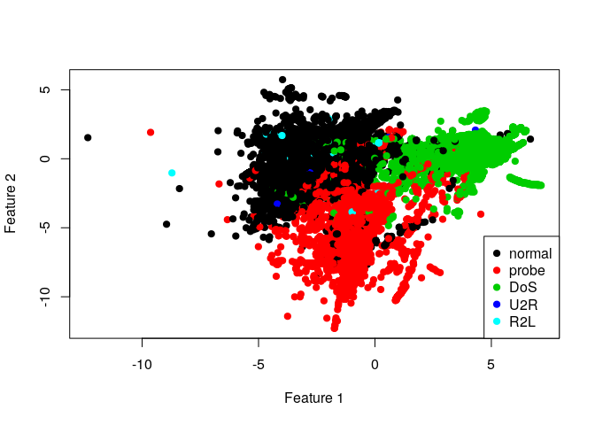

```r
#Fisher mapping
if(!require("MASS")) install.packages("MASS")
library("MASS")

r <- lda(formula=label~., data=a)
coef <- r$scaling
f <- as.matrix(a[,-ncol(a)]) %*% coef
f <- as.data.frame(f)
f$label <- a$label
a <- f

#apply on test set
g <- as.matrix(b[,-ncol(b)]) %*% coef
g <- as.data.frame(g)
g$label <- b$label
b <- g

png(filename="fisher_mapping.png")
plot(f[,1], f[,2], col=(f$label+1), pch=19, xlab = "Feature 1", ylab = "Feature 2")
legend("bottomright",legend = c("normal","probe","DoS","U2R","R2L"), col=1:5, pch = 19)
invisible(dev.off())

plot(f[,1], f[,2], col=(f$label+1), pch=19, xlab = "Feature 1", ylab = "Feature 2")
legend("bottomright",legend = c("normal","probe","DoS","U2R","R2L"), col=1:5, pch = 19)
```

```r
#Visualize a scatterplot with the first 3 features.
#plot3d(f[,1],f[,2],f[,3],col=(f$label+1),pch=19, xlab = "Feature 1", ylab = "Feature 2")
#legend3d("topright",legend = c("normal","probe","DoS","U2R","R2L"), col=1:5, pch = 19)
```

## Normal-against-all

Set up the class “normal” versus all other classes, and create a small training set and validation set for tuning the hyperparameters of different classifiers.

```r
#normal-vs-all
#rearrange labels
A <- a[a$label==0,]
B <- a[a$label!=0,]
B$label <- rep(1,dim(B)[1]) #outliers
za <- A
mean_normal <- apply(A[,-ncol(A)],2,mean)

#rearrange labels (test set)
zb <- b
zb$label[zb$label!=0] <- 1

a0 <- A
a1 <- B
ind0 <- sample(c(1:dim(a0)[1]),size=min(1000,dim(a0)[1]),replace=FALSE)
ind1 <- sample(c(1:dim(a1)[1]),size=min(1000,dim(a1)[1]),replace=FALSE)
a_val <- rbind(a0[ind0[1:min(500,floor(length(ind0)/2))],],
               a1[ind1[1:min(500,floor(length(ind1)/2))],])
a_train <- rbind(a0[ind0[(min(500,floor(length(ind0)/2))+1):min(1000,length(ind0))],],
                         a1[ind1[(min(500,floor(length(ind1)/2))+1):min(1000,length(ind1))],])
```

### Relative density one-class classifier (RDOCC)

Train a relative density one-class classifier on normal-vs.-all case. the hyperparameters of the classifier are estimated in the same manner as described previously. Finally, the ROC curve and the AUC value are computed and stored.

```r
k <- seq(1,min(sum(a_train[,ncol(a_train)]==0),20),by=2)
fracrej <- seq(0.01,0.3,length.out = 10)
h <- seq(0.01,10,length.out = 10)

l <- tune_rdc(a_train,a_val,fracrej,k,h,verbose=FALSE)
fracrej_opt <- l$fracrej_opt
k_opt <- l$k_opt
h_opt <- l$h_opt

Yl <- za
out <- rdocc_scalable(as.matrix(Yl),as.matrix(zb), h=h_opt, k=k_opt,
                      fracrej=fracrej_opt, verbose=FALSE)
pred <- out[[1]]
cf <- confusionMatrix(factor(pred,levels=c(0,1)),
                      factor(zb[,ncol(zb)],levels=c(0,1)),positive="1")
cntN_rdc <- as.numeric(pred==0)
print(cf)
```

```
## Confusion Matrix and Statistics
##
##           Reference
## Prediction    0    1
##          0 8774 4794
##          1  937 8039
##
##                Accuracy : 0.7458
##                  95% CI : (0.74, 0.7515)
##     No Information Rate : 0.5692
##     P-Value [Acc > NIR] : < 2.2e-16
##
##                   Kappa : 0.5055
##
##  Mcnemar's Test P-Value : < 2.2e-16
##
##             Sensitivity : 0.6264
##             Specificity : 0.9035
##          Pos Pred Value : 0.8956
##          Neg Pred Value : 0.6467
##              Prevalence : 0.5692
##          Detection Rate : 0.3566
##    Detection Prevalence : 0.3982
##       Balanced Accuracy : 0.7650
##
##        'Positive' Class : 1
##
```

```r
#roc: vary fracrej parameter and test performance on test set
R <- c(seq(1,0.1,length.out = 5),seq(0.09,0,length.out=5))
error_inliers <- error_outliers <- numeric(0)
for (i in seq_along(R)){
  l <- rdocc_scalable(as.matrix(Yl), as.matrix(zb), h=h_opt, k=k_opt,
                      fracrej = R[i], verbose=FALSE)
  L <- l[[1]]
  error_outliers[i] <- sum(L==0 & zb[,ncol(zb)]==1)
  error_inliers[i] <- sum(L==1 & zb[,ncol(zb)]==0)
}

y_normal_rdc <- 1 - (error_inliers / sum(zb[,ncol(zb)]==0)) #frac targets accepted
x_normal_rdc <- (error_outliers / sum(zb[,ncol(zb)]==1)) #frac outliers accepted
auc_normal_rdc <- auc(x_normal_rdc,y_normal_rdc)
```

### Median one-class classifier (MOCC)

Train MOCC on normal-vs.-all case. the hyperparameters of the classifier are estimated in the same manner as described previously. Finally, the ROC curve and the AUC value are computed and stored.

```r
k <- seq(1,min(sum(a_train[,ncol(a_train)]==0),20),by=2)
fracrej <- seq(0.01,0.3,length.out = 10)

l <- tune_mocc(a_train,a_val,fracrej,k,verbose=FALSE)
fracrej_opt <- l$fracrej_opt
k_opt <- l$k_opt

Yl <- za
out <- mocc_scalable(as.matrix(Yl),as.matrix(zb), k=k_opt,
                      fracrej=fracrej_opt, verbose=FALSE)
pred <- out[[1]]
cf <- confusionMatrix(factor(pred,levels=c(0,1)),
                      factor(zb[,ncol(zb)],levels=c(0,1)),positive="1")
cntN_mocc <- as.numeric(pred==0)
print(cf)
```

```
## Confusion Matrix and Statistics
##
##           Reference
## Prediction     0     1
##          0  8584  1253
##          1  1127 11580
##
##                Accuracy : 0.8944
##                  95% CI : (0.8903, 0.8984)
##     No Information Rate : 0.5692
##     P-Value [Acc > NIR] : <2e-16
##
##                   Kappa : 0.7851
##
##  Mcnemar's Test P-Value : 0.0104
##
##             Sensitivity : 0.9024
##             Specificity : 0.8839
##          Pos Pred Value : 0.9113
##          Neg Pred Value : 0.8726
##              Prevalence : 0.5692
##          Detection Rate : 0.5137
##    Detection Prevalence : 0.5637
##       Balanced Accuracy : 0.8932
##
##        'Positive' Class : 1
##
```

```r
#roc: vary fracrej parameter and test performance on test set
R <- c(seq(1,0.1,length.out = 5),seq(0.09,0,length.out=5))
error_inliers <- error_outliers <- numeric(0)
for (i in seq_along(R)){
  l <- mocc_scalable(as.matrix(Yl), as.matrix(zb), k=k_opt,
                      fracrej = R[i], verbose=FALSE)
  L <- l[[1]]
  error_outliers[i] <- sum(L==0 & zb[,ncol(zb)]==1)
  error_inliers[i] <- sum(L==1 & zb[,ncol(zb)]==0)
}

y_normal_mocc <- 1 - (error_inliers / sum(zb[,ncol(zb)]==0)) #frac targets accepted
x_normal_mocc <- (error_outliers / sum(zb[,ncol(zb)]==1)) #frac outliers accepted
auc_normal_mocc <- auc(x_normal_mocc,y_normal_mocc)
```

### Isolation forest

Train an isolation forest classifier on normal-vs.-all case. the hyperparameters of the classifier are estimated in the same manner as described previously. Finally, the ROC curve and the AUC value are computed and stored.

```r
#optimize hyperparameters
fracrej <- seq(0.01,0.3,length.out = 10)
l <-suppressMessages(tune_iforest(a_train,a_val,fracrej,verbose=FALSE))
fracrej_opt <- l$fracrej_opt

Yl <- za
x <- as.data.frame(Yl)
y <- as.data.frame(zb)
colnames(y) <- colnames(x)

out <- suppressMessages(iForest(x,y,fracrej=fracrej_opt, sample_size = dim(x)[1]))
pred <- out[[1]]
cf <- confusionMatrix(factor(pred,levels=c(0,1)),
                      factor(y[,ncol(y)], levels=c(0,1)), positive="1")
cntN_rf <- as.numeric(pred==0)
print(cf)
```

```
## Confusion Matrix and Statistics
##
##           Reference
## Prediction     0     1
##          0  8872  2533
##          1   839 10300
##
##                Accuracy : 0.8504
##                  95% CI : (0.8457, 0.8551)
##     No Information Rate : 0.5692
##     P-Value [Acc > NIR] : < 2.2e-16
##
##                   Kappa : 0.7013
##
##  Mcnemar's Test P-Value : < 2.2e-16
##
##             Sensitivity : 0.8026
##             Specificity : 0.9136
##          Pos Pred Value : 0.9247
##          Neg Pred Value : 0.7779
##              Prevalence : 0.5692
##          Detection Rate : 0.4569
##    Detection Prevalence : 0.4941
##       Balanced Accuracy : 0.8581
##
##        'Positive' Class : 1
##
```

```r
#roc: vary fracrej parameter and test performance on test set
R <- c(seq(1,0.1,length.out = 5),seq(0.09,0,length.out=5))
error_inliers <- error_outliers <- numeric(0)
for (i in seq_along(R)){
  l <- suppressMessages(iForest(x,y,fracrej=R[i], sample_size = dim(x)[1]))
  L <- l[[1]]
  error_outliers[i] <- sum(L==0 & y[,ncol(y)]==1)
  error_inliers[i] <- sum(L==1 & y[,ncol(y)]==0)
}

y_normal_rf <- 1 - (error_inliers / sum(y[,ncol(y)]==0)) #frac targets accepted
x_normal_rf <- (error_outliers / sum(y[,ncol(y)]==1)) #frac outliers accepted
auc_normal_rf <- auc(x_normal_rf,y_normal_rf)
```

### Support vector machine

Train a support vector machine on normal-vs.-all case. the hyperparameters of the classifier are estimated in the same manner as described previously. Finally, the ROC curve and the AUC value are computed and stored.

```r
#optimize hyperparameters
nu <- seq(0.01,0.99,length.out = 40)
gamma <- seq(0.01,0.99,length.out = 40)

l <- tune_svm(a_train,a_val,nu,gamma,verbose=FALSE)
nu_opt <- l$nu_opt
gamma_opt <- l$gamma_opt

Yl <- za
x <- as.data.frame(Yl)
y <- as.data.frame(zb)
colnames(y) <- colnames(x)

model <- svm(x = x[,-ncol(x)], y = x[,ncol(x)], type="one-classification",kernel="radial",
             nu=nu_opt,gamma = gamma_opt)

#Test the model on test set
pred <- predict(model, y[,-ncol(y)])
cf <- confusionMatrix(factor(as.numeric(!pred),levels=c(0,1)),
                      factor(y[,ncol(y)],levels=c(0,1)),positive="1")
cntN_svm <- as.numeric(!pred==0)
print(cf)
```

```
## Confusion Matrix and Statistics
##
##           Reference
## Prediction    0    1
##          0 9269 3165
##          1  442 9668
##
##                Accuracy : 0.84
##                  95% CI : (0.8352, 0.8448)
##     No Information Rate : 0.5692
##     P-Value [Acc > NIR] : < 2.2e-16
##
##                   Kappa : 0.6845
##
##  Mcnemar's Test P-Value : < 2.2e-16
##
##             Sensitivity : 0.7534
##             Specificity : 0.9545
##          Pos Pred Value : 0.9563
##          Neg Pred Value : 0.7455
##              Prevalence : 0.5692
##          Detection Rate : 0.4289
##    Detection Prevalence : 0.4485
##       Balanced Accuracy : 0.8539
##
##        'Positive' Class : 1
##
```

```r
#roc
predtest <- predict(model,y[,-ncol(y)],decision.values=TRUE)
lp <- attributes(predtest)$decision.values
R <- seq(max(lp),min(lp),length.out=10)
error_inliers <- error_outliers <- numeric(0)
for (i in seq_along(R)){
  L <- as.numeric(lp < R[i])
  error_outliers[i] <- sum(L==0 & y[,ncol(y)]==1)
  error_inliers[i] <- sum(L==1 & y[,ncol(y)]==0)
}
y_normal_svm <- 1 - (error_inliers / sum(y[,ncol(y)]==0)) #frac targets accepted
x_normal_svm <- (error_outliers / sum(y[,ncol(y)]==1)) #frac outliers accepted
auc_normal_svm <- auc(x_normal_svm,y_normal_svm)
```

### Local outlier factor

Train a local outlier factor classifier on normal-vs.-all case. the hyperparameters of the classifier are estimated in the same manner as described previously. Finally, the ROC curve and the AUC value are computed and stored.

```r
#optimize hyperparameters
a_val <- rbind(a0[ind0[1:min(50,floor(length(ind0)/2))],],
               a1[ind1[1:min(50,floor(length(ind1)/2))],])
a_train <- rbind(a0[ind0[(min(50,floor(length(ind0)/2))+1):min(100,length(ind0))],],
                         a1[ind1[(min(50,floor(length(ind1)/2))+1):min(100,length(ind1))],])

fracrej <- seq(0.01,0.3,length.out = 10)
k <- seq(2,min(20,sum(a_train$label==0)-1),by=3)

l <- tune_lof(a_train,a_val,fracrej,k,verbose=FALSE)
fracrej_opt <- l$fracrej_opt
k_opt <- l$k_opt

b0 <- zb[zb$label==0,]
b1 <- zb[zb$label==1,]
ind0 <- sample(c(1:dim(b0)[1]),size=min(100,dim(b0)[1]),replace=FALSE)
ind1 <- sample(c(1:dim(b1)[1]),size=min(100,dim(b1)[1]),replace=FALSE)
b_test <- rbind(b0[ind0,],b1[ind1,])

Yl <- a_train[a_train$label==0,]
x <- as.data.frame(Yl)
y <- as.data.frame(b_test)
colnames(y) <- colnames(x)

out <- lof_wrapper(x, y, k = k_opt, fracrej = fracrej_opt, cores=1)
pred <- out[[1]]
cf <- confusionMatrix(factor(pred,levels=c(0,1)),
                      factor(y[,ncol(y)], levels=c(0,1)), positive="1")
cntN_lof <- as.numeric(pred==0)
print(cf)
```

```
## Confusion Matrix and Statistics
##
##           Reference
## Prediction  0  1
##          0 95 33
##          1  5 67
##
##                Accuracy : 0.81
##                  95% CI : (0.7487, 0.8619)
##     No Information Rate : 0.5
##     P-Value [Acc > NIR] : < 2.2e-16
##
##                   Kappa : 0.62
##
##  Mcnemar's Test P-Value : 1.187e-05
##
##             Sensitivity : 0.6700
##             Specificity : 0.9500
##          Pos Pred Value : 0.9306
##          Neg Pred Value : 0.7422
##              Prevalence : 0.5000
##          Detection Rate : 0.3350
##    Detection Prevalence : 0.3600
##       Balanced Accuracy : 0.8100
##
##        'Positive' Class : 1
##
```

```r
#roc
R <- c(seq(1,0.1,length.out = 5),seq(0.09,0,length.out=5))
error_inliers <- error_outliers <- numeric(0)
for (i in seq_along(R)){
  l <- lof_wrapper(x, y, k = k_opt, fracrej = R[i], cores=1)
  L <- l[[1]]
  error_outliers[i] <- sum(L==0 & y[,ncol(y)]==1)
  error_inliers[i] <- sum(L==1 & y[,ncol(y)]==0)
}

#Plot ROC curve
y_normal_lof <- 1 - (error_inliers / sum(y[,ncol(y)]==0)) #frac targets accepted
x_normal_lof <- (error_outliers / sum(y[,ncol(y)]==1)) #frac outliers accepted
auc_normal_lof <- auc(x_normal_lof,y_normal_lof)
```

### ROC/AUC comparison

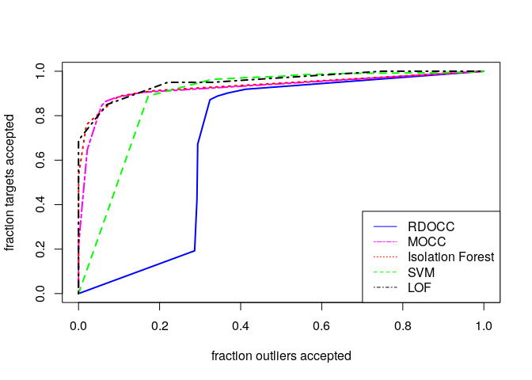

```r
png(filename="roc_normal_all.png")
plot(x_normal_rdc,y_normal_rdc,col="blue",type="l",lwd=2,
     xlab="fraction outliers accepted",ylab="fraction targets accepted")
lines(x_normal_mocc,y_normal_mocc,col="magenta",type="l",lty="twodash",lwd=2)
lines(x_normal_rf,y_normal_rf,col="red",type="l",lty = "dotted", lwd=2)
lines(x_normal_svm,y_normal_svm,col="green",type="l",lty = "dashed", lwd=2)
lines(x_normal_lof,y_normal_lof,col="black",type="l", lty = "dotdash", lwd=2)
legend("bottomright",legend=c("RDOCC","MOCC","Isolation Forest","SVM","LOF"),
       lty=c("solid","twodash","dotted","dashed","dotdash"),
       col=c("blue","magenta","red","green","black"))
invisible(dev.off())

#compare ROC/AUC
plot(x_normal_rdc,y_normal_rdc,col="blue",type="l",lwd=2,
     xlab="fraction outliers accepted",ylab="fraction targets accepted")
lines(x_normal_mocc,y_normal_mocc,col="magenta",type="l",lty="twodash",lwd=2)
lines(x_normal_rf,y_normal_rf,col="red",type="l",lty = "dotted", lwd=2)
lines(x_normal_svm,y_normal_svm,col="green",type="l",lty = "dashed", lwd=2)
lines(x_normal_lof,y_normal_lof,col="black",type="l", lty = "dotdash", lwd=2)
legend("bottomright",legend=c("RDOCC","MOCC","Isolation Forest","SVM","LOF"),
       lty=c("solid","twodash","dotted","dashed","dotdash"),
       col=c("blue","magenta","red","green","black"))
```

```r
dfauc_normal <- data.frame(class = c("RDOCC","MOCC","Isolation Forest","SVM","LOF"),
                        AUC = c(auc_normal_rdc, auc_normal_mocc, auc_normal_rf,
                                auc_normal_svm, auc_normal_lof))
print(dfauc_normal)
```

```
##              class       AUC
## 1            RDOCC 0.6967809
## 2             MOCC 0.9271178
## 3 Isolation Forest 0.9350764
## 4              SVM 0.8830103
## 5              LOF 0.9530000
```

## Probe-against-all

Set up the class “probe” versus all other classes, and create a small training set and validation set for tuning the hyperparameters of different classifiers.

```r
#Probe-vs-all
A <- a[a$label==1,]
B <- a[a$label!=1,]
A$label <- rep(0,dim(A)[1]) #targets
B$label <- rep(1,dim(B)[1]) #outliers
za <- A
mean_probe <- apply(A[,-ncol(A)],2,mean)

#rearrange labels (test set)
zb <- b
zb$label[zb$label!=1] <- -1
zb$label[zb$label==1] <- 0
zb$label[zb$label==-1] <- 1

a0 <- A
a1 <- B
ind0 <- sample(c(1:dim(a0)[1]),size=min(1000,dim(a0)[1]),replace=FALSE)
ind1 <- sample(c(1:dim(a1)[1]),size=min(1000,dim(a1)[1]),replace=FALSE)
a_val <- rbind(a0[ind0[1:min(500,floor(length(ind0)/2))],],
               a1[ind1[1:min(500,floor(length(ind1)/2))],])
a_train <- rbind(a0[ind0[(min(500,floor(length(ind0)/2))+1):min(1000,length(ind0))],],
                         a1[ind1[(min(500,floor(length(ind1)/2))+1):min(1000,length(ind1))],])
```

### Relative density one-class classifier (RDOCC)

Train a relative density one-class classifier on probe-vs.-all case. The value of the hyperparameters are estimated in the same manner as described previously. Finally, the ROC curve and the AUC value are computed and stored.

```r
k <- seq(1,min(sum(a_train[,ncol(a_train)]==0),20),by=2)
fracrej <- seq(0.01,0.3,length.out = 10)
h <- seq(0.01,10,length.out = 10)

l <- tune_rdc(a_train,a_val,fracrej,k,h,verbose=FALSE)
fracrej_opt <- l$fracrej_opt
k_opt <- l$k_opt
h_opt <- l$h_opt

Yl <- za
out <- rdocc_scalable(as.matrix(Yl),as.matrix(zb), h=h_opt, k=k_opt,
                      fracrej = fracrej_opt, verbose=FALSE)
pred <- out[[1]]
cf <- confusionMatrix(factor(pred,levels=c(0,1)),
                      factor(zb[,ncol(zb)],levels=c(0,1)), positive="1")
cntProbe_rdc <- as.numeric(pred==0)
print(cf)
```

```
## Confusion Matrix and Statistics
##
##           Reference
## Prediction     0     1
##          0  1649  2741
##          1   772 17382
##
##                Accuracy : 0.8442
##                  95% CI : (0.8394, 0.8489)
##     No Information Rate : 0.8926
##     P-Value [Acc > NIR] : 1
##
##                   Kappa : 0.4013
##
##  Mcnemar's Test P-Value : <2e-16
##
##             Sensitivity : 0.8638
##             Specificity : 0.6811
##          Pos Pred Value : 0.9575
##          Neg Pred Value : 0.3756
##              Prevalence : 0.8926
##          Detection Rate : 0.7710
##    Detection Prevalence : 0.8053
##       Balanced Accuracy : 0.7725
##
##        'Positive' Class : 1
##
```

```r
#roc: vary fracrej parameter and test performance on test set
R <- c(seq(1,0.1,length.out = 5),seq(0.09,0,length.out=5))
error_inliers <- error_outliers <- numeric(0)
for (i in seq_along(R)){
  l <- rdocc_scalable(as.matrix(Yl), as.matrix(zb), h=h_opt, k=k_opt,
                      fracrej = R[i],verbose=FALSE)
  L <- l[[1]]
  error_outliers[i] <- sum(L==0 & zb[,ncol(zb)]==1)
  error_inliers[i] <- sum(L==1 & zb[,ncol(zb)]==0)
}

y_probe_rdc <- 1 - (error_inliers / sum(zb[,ncol(zb)]==0)) #frac targets accepted
x_probe_rdc <- (error_outliers / sum(zb[,ncol(zb)]==1)) #frac outliers accepted
auc_probe_rdc <- auc(x_probe_rdc,y_probe_rdc)
```

### Median one-class classifier (MOCC)

Train MOCC on probe-vs.-all case. the hyperparameters of the classifier are estimated in the same manner as described previously. Finally, the ROC curve and the AUC value are computed and stored.

```r
k <- seq(1,min(sum(a_train[,ncol(a_train)]==0),20),by=2)
fracrej <- seq(0.01,0.3,length.out = 10)

l <- tune_mocc(a_train,a_val,fracrej,k,verbose=FALSE)
fracrej_opt <- l$fracrej_opt
k_opt <- l$k_opt

Yl <- za
out <- mocc_scalable(as.matrix(Yl),as.matrix(zb), k=k_opt,
                      fracrej=fracrej_opt, verbose=FALSE)
pred <- out[[1]]
cf <- confusionMatrix(factor(pred,levels=c(0,1)),
                      factor(zb[,ncol(zb)],levels=c(0,1)), positive="1")
cntProbe_mocc <- as.numeric(pred==0)
print(cf)
```

```
## Confusion Matrix and Statistics
##
##           Reference
## Prediction     0     1
##          0   823   230
##          1  1598 19893
##
##                Accuracy : 0.9189
##                  95% CI : (0.9153, 0.9224)
##     No Information Rate : 0.8926
##     P-Value [Acc > NIR] : < 2.2e-16
##
##                   Kappa : 0.4372
##
##  Mcnemar's Test P-Value : < 2.2e-16
##
##             Sensitivity : 0.9886
##             Specificity : 0.3399
##          Pos Pred Value : 0.9256
##          Neg Pred Value : 0.7816
##              Prevalence : 0.8926
##          Detection Rate : 0.8824
##    Detection Prevalence : 0.9533
##       Balanced Accuracy : 0.6643
##
##        'Positive' Class : 1
##
```

```r
#roc: vary fracrej parameter and test performance on test set
R <- c(seq(1,0.1,length.out = 5),seq(0.09,0,length.out=5))
error_inliers <- error_outliers <- numeric(0)
for (i in seq_along(R)){
  l <- mocc_scalable(as.matrix(Yl), as.matrix(zb), k=k_opt,
                      fracrej = R[i], verbose=FALSE)
  L <- l[[1]]
  error_outliers[i] <- sum(L==0 & zb[,ncol(zb)]==1)
  error_inliers[i] <- sum(L==1 & zb[,ncol(zb)]==0)
}

y_probe_mocc <- 1 - (error_inliers / sum(zb[,ncol(zb)]==0)) #frac targets accepted
x_probe_mocc <- (error_outliers / sum(zb[,ncol(zb)]==1)) #frac outliers accepted
auc_probe_mocc <- auc(x_probe_mocc,y_probe_mocc)
```

### Isolation forest

Train an isolation forest classifier on probe-vs.-all case. The value of the hyperparameters are estimated in the same manner as described previously. Finally, the ROC curve and the AUC value are computed and stored.

```r
#optimize hyperparameters
fracrej <- seq(0.01,0.3,length.out = 10)

l <- suppressMessages(tune_iforest(a_train,a_val,fracrej,verbose=FALSE))
fracrej_opt <- l$fracrej_opt

Yl <- za
x <- as.data.frame(Yl)
y <- as.data.frame(zb)
colnames(y) <- colnames(x)

out <- suppressMessages(iForest(x,y,fracrej= fracrej_opt, sample_size = dim(x)[1]))
pred <- out[[1]]
cf <- confusionMatrix(factor(pred,levels=c(0,1)),
                      factor(y[,ncol(y)],levels=c(0,1)), positive="1")
cntProbe_rf <- as.numeric(pred==0)
print(cf)
```

```
## Confusion Matrix and Statistics
##
##           Reference
## Prediction     0     1
##          0  1553  1820
##          1   868 18303
##
##                Accuracy : 0.8808
##                  95% CI : (0.8765, 0.885)
##     No Information Rate : 0.8926
##     P-Value [Acc > NIR] : 1
##
##                   Kappa : 0.4698
##
##  Mcnemar's Test P-Value : <2e-16
##
##             Sensitivity : 0.9096
##             Specificity : 0.6415
##          Pos Pred Value : 0.9547
##          Neg Pred Value : 0.4604
##              Prevalence : 0.8926
##          Detection Rate : 0.8119
##    Detection Prevalence : 0.8504
##       Balanced Accuracy : 0.7755
##
##        'Positive' Class : 1
##
```

```r
#roc
R <- c(seq(1,0.1,length.out = 5),seq(0.09,0,length.out=5))
error_inliers <- error_outliers <- numeric(0)
for (i in seq_along(R)){
  l <- suppressMessages(iForest(x,y,fracrej=R[i], sample_size = dim(x)[1]))
  L <- l[[1]]
  error_outliers[i] <- sum(L==0 & y[,ncol(y)]==1)
  error_inliers[i] <- sum(L==1 & y[,ncol(y)]==0)
}

y_probe_rf <- 1 - (error_inliers / sum(y[,ncol(y)]==0)) #frac targets accepted
x_probe_rf <- (error_outliers / sum(y[,ncol(y)]==1)) #frac outliers accepted
auc_probe_rf <- auc(x_probe_rf,y_probe_rf)
```

### Support vector machine

Train a support vector machine on probe-vs.-all case. The value of hyperparameterss are estimated in the same manner as described previously. Finally, the ROC curve and the AUC value are computed and stored.

```r
#optimize hyperparameters
nu <- seq(0.01,0.99,length.out = 40)
gamma <- seq(0.01,0.99,length.out = 40)

l <- tune_svm(a_train,a_val,nu,gamma,verbose=FALSE)
nu_opt <- l$nu_opt
gamma_opt <- l$gamma_opt

Yl <- za
x <- as.data.frame(Yl)
y <- as.data.frame(zb)
colnames(y) <- colnames(x)

model <- svm(x = x[,-ncol(x)], y = x[,ncol(x)], type="one-classification",kernel="radial",
             nu=nu_opt,gamma = gamma_opt)

#Test the model on test set
pred <- predict(model, y[,-ncol(y)])
cf <- confusionMatrix(factor(as.numeric(!pred),levels=c(0,1)),
                      factor(y[,ncol(y)],levels=c(0,1)), positive="1")
cntProbe_svm <- as.numeric(!pred==0)
print(cf)
```

```
## Confusion Matrix and Statistics
##
##           Reference
## Prediction     0     1
##          0  2021 10877
##          1   400  9246
##
##                Accuracy : 0.4998
##                  95% CI : (0.4932, 0.5063)
##     No Information Rate : 0.8926
##     P-Value [Acc > NIR] : 1
##
##                   Kappa : 0.1013
##
##  Mcnemar's Test P-Value : <2e-16
##
##             Sensitivity : 0.4595
##             Specificity : 0.8348
##          Pos Pred Value : 0.9585
##          Neg Pred Value : 0.1567
##              Prevalence : 0.8926
##          Detection Rate : 0.4101
##    Detection Prevalence : 0.4279
##       Balanced Accuracy : 0.6471
##
##        'Positive' Class : 1
##
```

```r
#roc
predtest <- predict(model,y[,-ncol(y)],decision.values=TRUE)
lp <- attributes(predtest)$decision.values
R <- seq(max(lp),min(lp),length.out=10)
error_inliers <- error_outliers <- numeric(0)
for (i in seq_along(R)){
  L <- as.numeric(lp < R[i])
  error_outliers[i] <- sum(L==0 & y[,ncol(y)]==1)
  error_inliers[i] <- sum(L==1 & y[,ncol(y)]==0)
}
y_probe_svm <- 1 - (error_inliers / sum(y[,ncol(y)]==0)) #frac targets accepted
x_probe_svm <- (error_outliers / sum(y[,ncol(y)]==1)) #frac outliers accepted
auc_probe_svm <- auc(x_probe_svm,y_probe_svm)
```

### Local outlier factor

Train a local outlier factor classifier on probe-vs.-all case. The value of hyperparameterss are estimated in the same manner as described previously. Finally, the ROC curve and the AUC value are computed and stored.

```r
#optimize hyperparameters
a_val <- rbind(a0[ind0[1:min(50,floor(length(ind0)/2))],],
               a1[ind1[1:min(50,floor(length(ind1)/2))],])
a_train <- rbind(a0[ind0[(min(50,floor(length(ind0)/2))+1):min(100,length(ind0))],],
                         a1[ind1[(min(50,floor(length(ind1)/2))+1):min(100,length(ind1))],])

fracrej <- seq(0.01,0.3,length.out = 10)
k <- seq(2,min(20,sum(a_train$label==0)-1),by=3)

l <- tune_lof(a_train,a_val,fracrej,k,verbose=FALSE)
fracrej_opt <- l$fracrej_opt
k_opt <- l$k_opt

b0 <- zb[zb$label==0,]
b1 <- zb[zb$label==1,]
ind0 <- sample(c(1:dim(b0)[1]),size=min(100,dim(b0)[1]),replace=FALSE)
ind1 <- sample(c(1:dim(b1)[1]),size=min(100,dim(b1)[1]),replace=FALSE)
b_test <- rbind(b0[ind0,],b1[ind1,])

Yl <- a_train[a_train$label==0,]
x <- as.data.frame(Yl)
y <- as.data.frame(b_test)
colnames(y) <- colnames(x)

out <- lof_wrapper(x, y, k = k_opt, fracrej = fracrej_opt, cores=1)
pred <- out[[1]]
cf <- confusionMatrix(factor(pred,levels=c(0,1)),
                      factor(y[,ncol(y)],levels=c(0,1)), positive="1")
cntProbe_lof <- as.numeric(pred==0)
print(cf)
```

```
## Confusion Matrix and Statistics
##
##           Reference
## Prediction  0  1
##          0 85 12
##          1 15 88
##
##                Accuracy : 0.865
##                  95% CI : (0.8097, 0.9091)
##     No Information Rate : 0.5
##     P-Value [Acc > NIR] : <2e-16
##
##                   Kappa : 0.73
##
##  Mcnemar's Test P-Value : 0.7003
##
##             Sensitivity : 0.8800
##             Specificity : 0.8500
##          Pos Pred Value : 0.8544
##          Neg Pred Value : 0.8763
##              Prevalence : 0.5000
##          Detection Rate : 0.4400
##    Detection Prevalence : 0.5150
##       Balanced Accuracy : 0.8650
##
##        'Positive' Class : 1
##
```

```r
#roc
R <- c(seq(1,0.1,length.out = 5),seq(0.09,0,length.out=5))
error_inliers <- error_outliers <- numeric(0)
for (i in seq_along(R)){
  l <- lof_wrapper(x, y, k = k_opt, fracrej = R[i], cores=1)
  L <- l[[1]]
  error_outliers[i] <- sum(L==0 & y[,ncol(y)]==1)
  error_inliers[i] <- sum(L==1 & y[,ncol(y)]==0)
}

y_probe_lof <- 1 - (error_inliers / sum(y[,ncol(y)]==0)) #frac targets accepted
x_probe_lof <- (error_outliers / sum(y[,ncol(y)]==1)) #frac outliers accepted
auc_probe_lof <- auc(x_probe_lof,y_probe_lof)
```

### ROC/AUC comparison

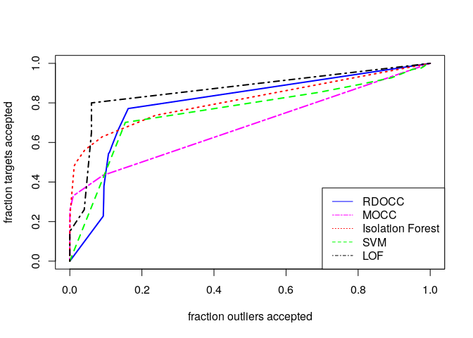

```r
png(filename="roc_probe_all.png")
plot(x_probe_rdc,y_probe_rdc,col="blue",type="l",lwd=2,
     xlab="fraction outliers accepted",ylab="fraction targets accepted")
lines(x_probe_mocc,y_probe_mocc,col="magenta",type="l",lty="twodash",lwd=2)
lines(x_probe_rf,y_probe_rf,col="red",type="l",lty = "dotted", lwd=2)
lines(x_probe_svm,y_probe_svm,col="green",type="l",lty = "dashed", lwd=2)
lines(x_probe_lof,y_probe_lof,col="black",type="l", lty = "dotdash", lwd=2)
legend("bottomright",legend=c("RDOCC","MOCC","Isolation Forest","SVM","LOF"),
       lty=c("solid","twodash","dotted","dashed","dotdash"),
       col=c("blue","magenta","red","green","black"))
invisible(dev.off())

#compare ROC/AUC
plot(x_probe_rdc,y_probe_rdc,col="blue",type="l",lwd=2,
     xlab="fraction outliers accepted",ylab="fraction targets accepted")
lines(x_probe_mocc,y_probe_mocc,col="magenta",type="l",lty="twodash",lwd=2)
lines(x_probe_rf,y_probe_rf,col="red",type="l",lty = "dotted", lwd=2)
lines(x_probe_svm,y_probe_svm,col="green",type="l",lty = "dashed", lwd=2)
lines(x_probe_lof,y_probe_lof,col="black",type="l", lty = "dotdash", lwd=2)
legend("bottomright",legend=c("RDOCC","MOCC","Isolation Forest","SVM","LOF"),
       lty=c("solid","twodash","dotted","dashed","dotdash"),
       col=c("blue","magenta","red","green","black"))
```

```r
dfauc_probe <- data.frame(class = c("RDOCC","MOCC","Isolation Forest","SVM","LOF"),
                        AUC = c(auc_probe_rdc, auc_probe_mocc, auc_probe_rf,
                                auc_probe_svm, auc_probe_lof))
print(dfauc_probe)
```

```
##              class       AUC
## 1            RDOCC 0.7953461
## 2             MOCC 0.6851716
## 3 Isolation Forest 0.8114577
## 4              SVM 0.7542257
## 5              LOF 0.8633000
```

## DoS-against-all

Set up the class “DoS” versus all other classes, and create a small training set and validation set for tuning hyperparameters of different classifiers.

```r
#DoS-vs-all
A <- a[a$label==2,]
B <- a[a$label!=2,]
A$label <- rep(0,dim(A)[1]) #targets
B$label <- rep(1,dim(B)[1]) #outliers
za <- A #rbind(A,B)
mean_dos <- apply(A[,-ncol(A)],2,mean)

#rearrange labels (test set)
zb <- b
zb$label[zb$label!=2] <- 1
zb$label[zb$label==2] <- 0

a0 <- A
a1 <- B
ind0 <- sample(c(1:dim(a0)[1]),size=min(1000,dim(a0)[1]),replace=FALSE)
ind1 <- sample(c(1:dim(a1)[1]),size=min(1000,dim(a1)[1]),replace=FALSE)
a_val <- rbind(a0[ind0[1:min(500,floor(length(ind0)/2))],],
               a1[ind1[1:min(500,floor(length(ind1)/2))],])
a_train <- rbind(a0[ind0[(min(500,floor(length(ind0)/2))+1):min(1000,length(ind0))],],
                         a1[ind1[(min(500,floor(length(ind1)/2))+1):min(1000,length(ind1))],])
```

### Relative density one-class classifier (RDOCC)

Train a relative density one-class classifier on DoS-vs.-all case. The value of the hyperparameters are estimated in the same manner as described previously. Finally, the ROC curve and the AUC value are computed and stored.

```r
k <- seq(1,min(sum(a_train[,ncol(a_train)]==0),20),by=2)
fracrej <- seq(0.01,0.3,length.out = 10)
h <- seq(0.01,10,length.out = 10)

l <- tune_rdc(a_train,a_val,fracrej,k,h,verbose=FALSE)
fracrej_opt <- l$fracrej_opt
k_opt <- l$k_opt
h_opt <- l$h_opt

Yl <- za
out <- rdocc_scalable(as.matrix(Yl),as.matrix(zb), h=h_opt, k=k_opt,
                      fracrej = fracrej_opt, verbose=FALSE)
pred <- out[[1]]
cf <- confusionMatrix(factor(pred,levels=c(0,1)),
                      factor(zb[,ncol(zb)],levels=c(0,1)), positive="1")
cntDoS_rdc <- as.numeric(pred==0)
print(cf)
```

```
## Confusion Matrix and Statistics
##
##           Reference
## Prediction     0     1
##          0  6020  2445
##          1  1438 12641
##
##                Accuracy : 0.8278
##                  95% CI : (0.8228, 0.8327)
##     No Information Rate : 0.6692
##     P-Value [Acc > NIR] : < 2.2e-16
##
##                   Kappa : 0.6238
##
##  Mcnemar's Test P-Value : < 2.2e-16
##
##             Sensitivity : 0.8379
##             Specificity : 0.8072
##          Pos Pred Value : 0.8979
##          Neg Pred Value : 0.7112
##              Prevalence : 0.6692
##          Detection Rate : 0.5607
##    Detection Prevalence : 0.6245
##       Balanced Accuracy : 0.8226
##
##        'Positive' Class : 1
##
```

```r
#roc: vary fracrej parameter and test performance on test set
R <- c(seq(1,0.1,length.out = 5),seq(0.09,0,length.out=5))
error_inliers <- error_outliers <- numeric(0)
for (i in seq_along(R)){
  l <- rdocc_scalable(as.matrix(Yl), as.matrix(zb), h=h_opt, k=k_opt,
                      fracrej = R[i],verbose=FALSE)
  L <- l[[1]]
  error_outliers[i] <- sum(L==0 & zb[,ncol(zb)]==1)
  error_inliers[i] <- sum(L==1 & zb[,ncol(zb)]==0)
}

y_dos_rdc <- 1 - (error_inliers / sum(zb[,ncol(zb)]==0)) #frac targets accepted
x_dos_rdc <- (error_outliers / sum(zb[,ncol(zb)]==1)) #frac outliers accepted
auc_dos_rdc <- auc(x_dos_rdc,y_dos_rdc)
```

### Median one-class classifier (MOCC)

Train MOCC on DoS-vs.-all case. the hyperparameters of the classifier are estimated in the same manner as described previously. Finally, the ROC curve and the AUC value are computed and stored.

```r
k <- seq(1,min(sum(a_train[,ncol(a_train)]==0),20),by=2)
fracrej <- seq(0.01,0.3,length.out = 10)

l <- tune_mocc(a_train,a_val,fracrej,k,verbose=FALSE)
fracrej_opt <- l$fracrej_opt
k_opt <- l$k_opt

Yl <- za
out <- mocc_scalable(as.matrix(Yl),as.matrix(zb), k=k_opt,
                      fracrej=fracrej_opt, verbose=FALSE)
pred <- out[[1]]
cf <- confusionMatrix(factor(pred,levels=c(0,1)),
                      factor(zb[,ncol(zb)],levels=c(0,1)), positive="1")
cntDoS_mocc <- as.numeric(pred==0)
print(cf)
```

```
## Confusion Matrix and Statistics
##
##           Reference
## Prediction     0     1
##          0  4912    20
##          1  2546 15066
##
##                Accuracy : 0.8862
##                  95% CI : (0.882, 0.8903)
##     No Information Rate : 0.6692
##     P-Value [Acc > NIR] : < 2.2e-16
##
##                   Kappa : 0.7188
##
##  Mcnemar's Test P-Value : < 2.2e-16
##
##             Sensitivity : 0.9987
##             Specificity : 0.6586
##          Pos Pred Value : 0.8554
##          Neg Pred Value : 0.9959
##              Prevalence : 0.6692
##          Detection Rate : 0.6683
##    Detection Prevalence : 0.7812
##       Balanced Accuracy : 0.8286
##
##        'Positive' Class : 1
##
```

```r
#roc: vary fracrej parameter and test performance on test set
R <- c(seq(1,0.1,length.out = 5),seq(0.09,0,length.out=5))
error_inliers <- error_outliers <- numeric(0)
for (i in seq_along(R)){
  l <- mocc_scalable(as.matrix(Yl), as.matrix(zb), k=k_opt,
                      fracrej = R[i], verbose=FALSE)
  L <- l[[1]]
  error_outliers[i] <- sum(L==0 & zb[,ncol(zb)]==1)
  error_inliers[i] <- sum(L==1 & zb[,ncol(zb)]==0)
}

y_dos_mocc <- 1 - (error_inliers / sum(zb[,ncol(zb)]==0)) #frac targets accepted
x_dos_mocc <- (error_outliers / sum(zb[,ncol(zb)]==1)) #frac outliers accepted
auc_dos_mocc <- auc(x_dos_mocc,y_dos_mocc)
```

### Isolation forest

Train an isolation forest classifier on DoS-vs.-all case. The value of the hyperparameters are estimated in the same manner as described previously. Finally, the ROC curve and the AUC value are computed and stored.

```r
#optimize hyperparameters
fracrej <- seq(0.01,0.3,length.out = 10)

l <- suppressMessages(tune_iforest(a_train,a_val,fracrej,verbose=FALSE))
fracrej_opt <- l$fracrej_opt

Yl <- za
x <- as.data.frame(Yl)
y <- as.data.frame(zb)
colnames(y) <- colnames(x)

out <- suppressMessages(iForest(x,y,fracrej= fracrej_opt, sample_size = dim(x)[1]))
pred <- out[[1]]
cf <- confusionMatrix(factor(pred,levels=c(0,1)),
                      factor(y[,ncol(y)],levels=c(0,1)), positive="1")
cntDoS_rf <- as.numeric(pred==0)
print(cf)
```

```
## Confusion Matrix and Statistics
##
##           Reference
## Prediction     0     1
##          0  5008    24
##          1  2450 15062
##
##                Accuracy : 0.8903
##                  95% CI : (0.8861, 0.8943)
##     No Information Rate : 0.6692
##     P-Value [Acc > NIR] : < 2.2e-16
##
##                   Kappa : 0.7299
##
##  Mcnemar's Test P-Value : < 2.2e-16
##
##             Sensitivity : 0.9984
##             Specificity : 0.6715
##          Pos Pred Value : 0.8601
##          Neg Pred Value : 0.9952
##              Prevalence : 0.6692
##          Detection Rate : 0.6681
##    Detection Prevalence : 0.7768
##       Balanced Accuracy : 0.8350
##
##        'Positive' Class : 1
##
```

```r
#roc
R <- c(seq(1,0.1,length.out = 5),seq(0.09,0,length.out=5))
error_inliers <- error_outliers <- numeric(0)
for (i in seq_along(R)){
  l <-suppressMessages(iForest(x,y,fracrej=R[i], sample_size = dim(x)[1]))
  L <- l[[1]]
  error_outliers[i] <- sum(L==0 & y[,ncol(y)]==1)
  error_inliers[i] <- sum(L==1 & y[,ncol(y)]==0)
}

y_dos_rf <- 1 - (error_inliers / sum(y[,ncol(y)]==0)) #frac targets accepted
x_dos_rf <- (error_outliers / sum(y[,ncol(y)]==1)) #frac outliers accepted
auc_dos_rf <- auc(x_dos_rf,y_dos_rf)
```

### Support vector machine

Train a support vector machine on DoS-vs.-all case. The value of hyperparameterss are estimated in the same manner as described previously. Finally, the ROC curve and the AUC value are computed and stored.

```r
#optimize hyperparameters
nu <- seq(0.01,0.99,length.out = 40)
gamma <- seq(0.01,0.99,length.out = 40)

l <- tune_svm(a_train,a_val,nu,gamma,verbose=FALSE)
nu_opt <- l$nu_opt
gamma_opt <- l$gamma_opt

Yl <- za
x <- as.data.frame(Yl)
y <- as.data.frame(zb)
colnames(y) <- colnames(x)

model <- svm(x = x[,-ncol(x)], y = x[,ncol(x)], type="one-classification",kernel="radial",
             nu=nu_opt,gamma = gamma_opt)

#Test the model on test set
pred <- predict(model, y[,-ncol(y)])
cf <- confusionMatrix(factor(as.numeric(!pred),levels=c(0,1)),
                      factor(y[,ncol(y)],levels=c(0,1)), positive="1")
cntDoS_svm <- as.numeric(!pred==0)
print(cf)
```

```
## Confusion Matrix and Statistics
##
##           Reference
## Prediction     0     1
##          0  5145    89
##          1  2313 14997
##
##                Accuracy : 0.8935
##                  95% CI : (0.8894, 0.8975)
##     No Information Rate : 0.6692
##     P-Value [Acc > NIR] : < 2.2e-16
##
##                   Kappa : 0.7397
##
##  Mcnemar's Test P-Value : < 2.2e-16
##
##             Sensitivity : 0.9941
##             Specificity : 0.6899
##          Pos Pred Value : 0.8664
##          Neg Pred Value : 0.9830
##              Prevalence : 0.6692
##          Detection Rate : 0.6652
##    Detection Prevalence : 0.7678
##       Balanced Accuracy : 0.8420
##
##        'Positive' Class : 1
##
```

```r
#roc
predtest <- predict(model,y[,-ncol(y)],decision.values=TRUE)
lp <- attributes(predtest)$decision.values
R <- seq(max(lp),min(lp),length.out=10)
error_inliers <- error_outliers <- numeric(0)
for (i in seq_along(R)){
  L <- as.numeric(lp < R[i])
  error_outliers[i] <- sum(L==0 & y[,ncol(y)]==1)
  error_inliers[i] <- sum(L==1 & y[,ncol(y)]==0)
}
y_dos_svm <- 1 - (error_inliers / sum(y[,ncol(y)]==0)) #frac targets accepted
x_dos_svm <- (error_outliers / sum(y[,ncol(y)]==1)) #frac outliers accepted
auc_dos_svm <- auc(x_dos_svm,y_dos_svm)
```

### Local outlier factor

Train a local outlier factor classifier on Dos-vs.-all case. The value of hyperparameterss are estimated in the same manner as described previously. Finally, the ROC curve and the AUC value are computed and stored.

```r
#optimize hyperparameters
a_val <- rbind(a0[ind0[1:min(50,floor(length(ind0)/2))],],
               a1[ind1[1:min(50,floor(length(ind1)/2))],])
a_train <- rbind(a0[ind0[(min(50,floor(length(ind0)/2))+1):min(100,length(ind0))],],
                         a1[ind1[(min(50,floor(length(ind1)/2))+1):min(100,length(ind1))],])

fracrej <- seq(0.01,0.3,length.out = 10)
k <- seq(2,min(20,sum(a_train$label==0)-1),by=3)

l <- tune_lof(a_train,a_val,fracrej,k,verbose=FALSE)
fracrej_opt <- l$fracrej_opt
k_opt <- l$k_opt

b0 <- zb[zb$label==0,]
b1 <- zb[zb$label==1,]
ind0 <- sample(c(1:dim(b0)[1]),size=min(100,dim(b0)[1]),replace=FALSE)
ind1 <- sample(c(1:dim(b1)[1]),size=min(100,dim(b1)[1]),replace=FALSE)
b_test <- rbind(b0[ind0,],b1[ind1,])

Yl <- a_train[a_train$label==0,]
x <- as.data.frame(Yl)
y <- as.data.frame(b_test)
colnames(y) <- colnames(x)

out <- lof_wrapper(x, y, k = k_opt, fracrej = fracrej_opt, cores=1)
pred <- out[[1]]
cf <- confusionMatrix(factor(pred,levels=c(0,1)),
                      factor(y[,ncol(y)],levels=c(0,1)), positive="1")
cntDoS_lof <- as.numeric(pred==0)
print(cf)
```

```
## Confusion Matrix and Statistics
##
##           Reference
## Prediction  0  1
##          0 62  2
##          1 38 98
##
##                Accuracy : 0.8
##                  95% CI : (0.7378, 0.8531)
##     No Information Rate : 0.5
##     P-Value [Acc > NIR] : < 2.2e-16
##
##                   Kappa : 0.6
##
##  Mcnemar's Test P-Value : 3.13e-08
##
##             Sensitivity : 0.9800
##             Specificity : 0.6200
##          Pos Pred Value : 0.7206
##          Neg Pred Value : 0.9688
##              Prevalence : 0.5000
##          Detection Rate : 0.4900
##    Detection Prevalence : 0.6800
##       Balanced Accuracy : 0.8000
##
##        'Positive' Class : 1
##
```

```r
#roc
R <- c(seq(1,0.1,length.out = 5),seq(0.09,0,length.out=5))
error_inliers <- error_outliers <- numeric(0)
for (i in seq_along(R)){
  l <- lof_wrapper(x, y, k = k_opt, fracrej = R[i], cores=1)
  L <- l[[1]]
  error_outliers[i] <- sum(L==0 & y[,ncol(y)]==1)
  error_inliers[i] <- sum(L==1 & y[,ncol(y)]==0)
}

y_dos_lof<- 1 - (error_inliers / sum(y[,ncol(y)]==0)) #frac targets accepted
x_dos_lof <- (error_outliers / sum(y[,ncol(y)]==1)) #frac outliers accepted
auc_dos_lof <- auc(x_dos_lof,y_dos_lof)
```

### ROC/AUC comparison

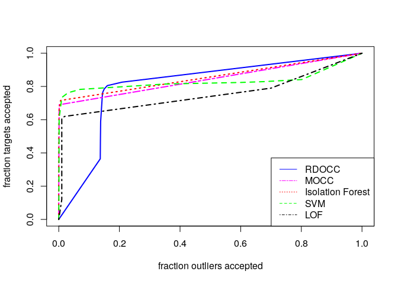

```r
png(filename="roc_dos_all.png")
plot(x_dos_rdc,y_dos_rdc,col="blue",type="l",lwd=2,
     xlab="fraction outliers accepted",ylab="fraction targets accepted")
lines(x_dos_mocc,y_dos_mocc,col="magenta",type="l",lty="twodash",lwd=2)
lines(x_dos_rf,y_dos_rf,col="red",type="l",lty = "dotted", lwd=2)
lines(x_dos_svm,y_dos_svm,col="green",type="l",lty = "dashed", lwd=2)
lines(x_dos_lof,y_dos_lof,col="black",type="l", lty = "dotdash", lwd=2)
legend("bottomright",legend=c("RDOCC","MOCC","Isolation Forest","SVM","LOF"),
       lty=c("solid","twodash","dotted","dashed","dotdash"),
       col=c("blue","magenta","red","green","black"))
invisible(dev.off())

#compare ROC/AUC
plot(x_dos_rdc,y_dos_rdc,col="blue",type="l",lwd=2,
     xlab="fraction outliers accepted",ylab="fraction targets accepted")
lines(x_dos_mocc,y_dos_mocc,col="magenta",type="l",lty="twodash",lwd=2)
lines(x_dos_rf,y_dos_rf,col="red",type="l",lty = "dotted", lwd=2)
lines(x_dos_svm,y_dos_svm,col="green",type="l",lty = "dashed", lwd=2)
lines(x_dos_lof,y_dos_lof,col="black",type="l", lty = "dotdash", lwd=2)
legend("bottomright",legend=c("RDOCC","MOCC","Isolation Forest","SVM","LOF"),
       lty=c("solid","twodash","dotted","dashed","dotdash"),
       col=c("blue","magenta","red","green","black"))
```

```r
dfauc_dos <- data.frame(class = c("RDOCC","MOCC","Isolation Forest","SVM","LOF"),
                        AUC = c(auc_dos_rdc, auc_dos_mocc, auc_dos_rf,
                                auc_dos_svm, auc_dos_lof))
print(dfauc_dos)
```

```
##              class       AUC
## 1            RDOCC 0.8042089
## 2             MOCC 0.8443768
## 3 Isolation Forest 0.8567667
## 4              SVM 0.8309032
## 5              LOF 0.7546500
```

## U2R-against-all

Set up the class “U2R” versus all other classes, and create a small training set and validation set for tuning Hyperparameters of different classifiers.

```r
A <- a[a$label==3,]
B <- a[a$label!=3,]
A$label <- rep(0,dim(A)[1]) #targets
B$label <- rep(1,dim(B)[1]) #outliers
za <- A
mean_u2r <- apply(A[,-ncol(A)],2,mean)

#rearrange labels (test set)
zb <- b
zb$label[zb$label!=3] <- 1
zb$label[zb$label==3] <- 0

a0 <- A
a1 <- B
ind0 <- sample(c(1:dim(a0)[1]),size=min(1000,dim(a0)[1]),replace=FALSE)
ind1 <- sample(c(1:dim(a1)[1]),size=min(1000,dim(a1)[1]),replace=FALSE)
a_val <- rbind(a0[ind0[1:min(500,floor(length(ind0)/2))],],
               a1[ind1[1:min(500,floor(length(ind1)/2))],])
a_train <- rbind(a0[ind0[(min(500,floor(length(ind0)/2))+1):min(1000,length(ind0))],],
                         a1[ind1[(min(500,floor(length(ind1)/2))+1):min(1000,length(ind1))],])
```

### Relative density one-class classifier (RDOCC)

Train a relative density one-class classifier on U2R-vs.-all case. The value of the hyperparameters are estimated in the same manner as described previously. Finally, the ROC curve and the AUC value are computed and stored.

```r
k <- seq(1,min(sum(a_train[,ncol(a_train)]==0),20),by=2)
fracrej <- seq(0.01,0.3,length.out = 10)
h <- seq(0.01,10,length.out = 10)

l <- tune_rdc(a_train,a_val,fracrej,k,h,verbose=FALSE)
fracrej_opt <- l$fracrej_opt
k_opt <- l$k_opt
h_opt <- l$h_opt

#classify
Yl <- za
out <- rdocc_scalable(as.matrix(Yl),as.matrix(zb), h=h_opt, k=k_opt,
                      fracrej = fracrej_opt,verbose=FALSE)
pred <- out[[1]]
cf <- confusionMatrix(factor(pred,levels=c(0,1)),
                      factor(zb[,ncol(zb)],levels=c(0,1)), positive="1")
cntU2R_rdc <- as.numeric(pred==0)
print(cf)
```

```
## Confusion Matrix and Statistics
##
##           Reference
## Prediction     0     1
##          0    35 10230
##          1    32 12247
##
##                Accuracy : 0.5448
##                  95% CI : (0.5383, 0.5513)
##     No Information Rate : 0.997
##     P-Value [Acc > NIR] : 1
##
##                   Kappa : 9e-04
##
##  Mcnemar's Test P-Value : <2e-16
##
##             Sensitivity : 0.54487
##             Specificity : 0.52239
##          Pos Pred Value : 0.99739
##          Neg Pred Value : 0.00341
##              Prevalence : 0.99703
##          Detection Rate : 0.54325
##    Detection Prevalence : 0.54467
##       Balanced Accuracy : 0.53363
##
##        'Positive' Class : 1
##
```

```r
#roc: vary fracrej parameter and test performance on test set
R <- c(seq(1,0.1,length.out = 5),seq(0.09,0,length.out=5))
error_inliers <- error_outliers <- numeric(0)
for (i in seq_along(R)){
  l <- rdocc_scalable(as.matrix(Yl), as.matrix(zb), h=h_opt, k=k_opt,
                      fracrej = R[i],verbose=FALSE)
  L <- l[[1]]
  error_outliers[i] <- sum(L==0 & zb[,ncol(zb)]==1)
  error_inliers[i] <- sum(L==1 & zb[,ncol(zb)]==0)
}

y_u2r_rdc <- 1 - (error_inliers / sum(zb[,ncol(zb)]==0)) #frac targets accepted
x_u2r_rdc <- (error_outliers / sum(zb[,ncol(zb)]==1)) #frac outliers accepted
auc_u2r_rdc <- auc(x_u2r_rdc,y_u2r_rdc)
```

### Median one-class classifier (MOCC)

Train MOCC on U2R-vs.-all case. the hyperparameters of the classifier are estimated in the same manner as described previously. Finally, the ROC curve and the AUC value are computed and stored.

```r
k <- seq(1,min(sum(a_train[,ncol(a_train)]==0),20),by=2)
fracrej <- seq(0.01,0.3,length.out = 10)

l <- tune_mocc(a_train,a_val,fracrej,k,verbose=FALSE)
fracrej_opt <- l$fracrej_opt
k_opt <- l$k_opt

Yl <- za
out <- mocc_scalable(as.matrix(Yl),as.matrix(zb), k=k_opt,
                      fracrej=fracrej_opt, verbose=FALSE)
pred <- out[[1]]
cf <- confusionMatrix(factor(pred,levels=c(0,1)),
                      factor(zb[,ncol(zb)],levels=c(0,1)), positive="1")
cntU2R_mocc <- as.numeric(pred==0)
print(cf)
```

```
## Confusion Matrix and Statistics
##
##           Reference
## Prediction     0     1
##          0    44 13216
##          1    23  9261
##
##                Accuracy : 0.4127
##                  95% CI : (0.4063, 0.4192)
##     No Information Rate : 0.997
##     P-Value [Acc > NIR] : 1
##
##                   Kappa : 7e-04
##
##  Mcnemar's Test P-Value : <2e-16
##
##             Sensitivity : 0.412021
##             Specificity : 0.656716
##          Pos Pred Value : 0.997523
##          Neg Pred Value : 0.003318
##              Prevalence : 0.997028
##          Detection Rate : 0.410797
##    Detection Prevalence : 0.411817
##       Balanced Accuracy : 0.534369
##
##        'Positive' Class : 1
##
```

```r
#roc: vary fracrej parameter and test performance on test set
R <- c(seq(1,0.1,length.out = 5),seq(0.09,0,length.out=5))
error_inliers <- error_outliers <- numeric(0)
for (i in seq_along(R)){
  l <- mocc_scalable(as.matrix(Yl), as.matrix(zb), k=k_opt,
                      fracrej = R[i], verbose=FALSE)
  L <- l[[1]]
  error_outliers[i] <- sum(L==0 & zb[,ncol(zb)]==1)
  error_inliers[i] <- sum(L==1 & zb[,ncol(zb)]==0)
}

y_u2r_mocc <- 1 - (error_inliers / sum(zb[,ncol(zb)]==0)) #frac targets accepted
x_u2r_mocc <- (error_outliers / sum(zb[,ncol(zb)]==1)) #frac outliers accepted
auc_u2r_mocc <- auc(x_u2r_mocc,y_u2r_mocc)
```

### Isolation forest

Train an isolation forest classifier on U2R-vs.-all case. The value of the hyperparameters are estimated in the same manner as described previously. Finally, the ROC curve and the AUC value are computed and stored.

```r
fracrej <- seq(0.01,0.3,length.out = 10)
l <- suppressMessages(tune_iforest(a_train,a_val,fracrej,verbose=FALSE))
fracrej_opt <- l$fracrej_opt

Yl <- za
x <- as.data.frame(Yl)
y <- as.data.frame(zb)
colnames(y) <- colnames(x)

out <-suppressMessages(iForest(x,y,fracrej=fracrej_opt, sample_size = dim(x)[1]))
pred <- out[[1]]
cf <- confusionMatrix(factor(pred,levels=c(0,1)),
                      factor(y[,ncol(y)],levels=c(0,1)), positive="1")
cntU2R_rf <- as.numeric(pred==0)
print(cf)
```

```
## Confusion Matrix and Statistics
##
##           Reference
## Prediction     0     1
##          0    39  4959
##          1    28 17518
##
##                Accuracy : 0.7788
##                  95% CI : (0.7733, 0.7842)
##     No Information Rate : 0.997
##     P-Value [Acc > NIR] : 1
##
##                   Kappa : 0.0096
##
##  Mcnemar's Test P-Value : <2e-16
##
##             Sensitivity : 0.779374
##             Specificity : 0.582090
##          Pos Pred Value : 0.998404
##          Neg Pred Value : 0.007803
##              Prevalence : 0.997028
##          Detection Rate : 0.777058
##    Detection Prevalence : 0.778300
##       Balanced Accuracy : 0.680732
##
##        'Positive' Class : 1
##
```

```r
#roc
R <- c(seq(1,0.1,length.out = 5),seq(0.09,0,length.out=5))
error_inliers <- error_outliers <- numeric(0)
for (i in seq_along(R)){
  l <- suppressMessages(iForest(x,y,fracrej=R[i], sample_size = dim(x)[1]))
  L <- l[[1]]
  error_outliers[i] <- sum(L==0 & y[,ncol(y)]==1)
  error_inliers[i] <- sum(L==1 & y[,ncol(y)]==0)
}

y_u2r_rf <- 1 - (error_inliers / sum(y[,ncol(y)]==0)) #frac targets accepted
x_u2r_rf <- (error_outliers / sum(y[,ncol(y)]==1)) #frac outliers accepted
auc_u2r_rf <- auc(x_u2r_rf,y_u2r_rf)
```

### Support vector machine

Train a support vector machine on U2R-vs.-all case. The value of hyperparameterss are estimated in the same manner as described previously. Finally, the ROC curve and the AUC value are computed and stored.

```r
#optimize hyperparameters
nu <- seq(0.01,0.99,length.out = 40)
gamma <- seq(0.01,0.99,length.out = 40)

l <- tune_svm(a_train,a_val,nu,gamma,verbose=FALSE)
nu_opt <- l$nu_opt
gamma_opt <- l$gamma_opt

Yl <- za
x <- as.data.frame(Yl)
y <- as.data.frame(zb)
colnames(y) <- colnames(x)

model <- svm(x = x[,-ncol(x)], y = x[,ncol(x)], type="one-classification",kernel="radial",
             nu=nu_opt,gamma = gamma_opt)

#Test the model on test set
pred <- predict(model, y[,-ncol(y)])
cf <- confusionMatrix(factor(as.numeric(!pred),levels=c(0,1)),
                      factor(y[,ncol(y)],levels=c(0,1)), positive="1")
cntU2R_svm <- as.numeric(!pred==0)
print(cf)
```

```
## Confusion Matrix and Statistics
##
##           Reference
## Prediction     0     1
##          0    30  1058
##          1    37 21419
##
##                Accuracy : 0.9514
##                  95% CI : (0.9485, 0.9542)
##     No Information Rate : 0.997
##     P-Value [Acc > NIR] : 1
##
##                   Kappa : 0.0466
##
##  Mcnemar's Test P-Value : <2e-16
##
##             Sensitivity : 0.95293
##             Specificity : 0.44776
##          Pos Pred Value : 0.99828
##          Neg Pred Value : 0.02757
##              Prevalence : 0.99703
##          Detection Rate : 0.95010
##    Detection Prevalence : 0.95174
##       Balanced Accuracy : 0.70035
##
##        'Positive' Class : 1
##
```

```r
#roc
predtest <- predict(model,y[,-ncol(y)],decision.values=TRUE)
lp <- attributes(predtest)$decision.values
R <- seq(max(lp),min(lp),length.out=10)
error_inliers <- error_outliers <- numeric(0)
for (i in seq_along(R)){
  L <- as.numeric(lp < R[i])
  error_outliers[i] <- sum(L==0 & y[,ncol(y)]==1)
  error_inliers[i] <- sum(L==1 & y[,ncol(y)]==0)
}
y_u2r_svm <- 1 - (error_inliers / sum(y[,ncol(y)]==0)) #frac targets accepted
x_u2r_svm <- (error_outliers / sum(y[,ncol(y)]==1)) #frac outliers accepted
auc_u2r_svm <- auc(x_u2r_svm,y_u2r_svm)
```

### Local outlier factor

Train a local outlier factor classifier on U2R-vs.-all case. The value of hyperparameterss are estimated in the same manner as described previously. Finally, the ROC curve and the AUC value are computed and stored.

```r
#optimize hyperparameters
a_val <- rbind(a0[ind0[1:min(50,floor(length(ind0)/2))],],
               a1[ind1[1:min(50,floor(length(ind1)/2))],])
a_train <- rbind(a0[ind0[(min(50,floor(length(ind0)/2))+1):min(100,length(ind0))],],
                         a1[ind1[(min(50,floor(length(ind1)/2))+1):min(100,length(ind1))],])

fracrej <- seq(0.01,0.3,length.out = 10)
k <- seq(2,min(20,sum(a_train$label==0)-1),by=3)

l <- tune_lof(a_train,a_val,fracrej,k,verbose=FALSE)
fracrej_opt <- l$fracrej_opt
k_opt <- l$k_opt

b0 <- zb[zb$label==0,]
b1 <- zb[zb$label==1,]
ind0 <- sample(c(1:dim(b0)[1]),size=min(100,dim(b0)[1]),replace=FALSE)
ind1 <- sample(c(1:dim(b1)[1]),size=min(100,dim(b1)[1]),replace=FALSE)
b_test <- rbind(b0[ind0,],b1[ind1,])

Yl <- a_train[a_train$label==0,]
x <- as.data.frame(Yl)
y <- as.data.frame(b_test)
colnames(y) <- colnames(x)

out <- lof_wrapper(x, y, k = k_opt, fracrej = fracrej_opt, cores=1)
pred <- out[[1]]
cf <- confusionMatrix(factor(pred,levels=c(0,1)),
                      factor(y[,ncol(y)],levels=c(0,1)), positive="1")
cntU2R_lof <- as.numeric(pred==0)
print(cf)
```

```
## Confusion Matrix and Statistics
##
##           Reference
## Prediction  0  1
##          0 21  4
##          1 46 96
##
##                Accuracy : 0.7006
##                  95% CI : (0.625, 0.7689)
##     No Information Rate : 0.5988
##     P-Value [Acc > NIR] : 0.004089
##
##                   Kappa : 0.305
##
##  Mcnemar's Test P-Value : 6.7e-09
##
##             Sensitivity : 0.9600
##             Specificity : 0.3134
##          Pos Pred Value : 0.6761
##          Neg Pred Value : 0.8400
##              Prevalence : 0.5988
##          Detection Rate : 0.5749
##    Detection Prevalence : 0.8503
##       Balanced Accuracy : 0.6367
##
##        'Positive' Class : 1
##
```

```r
#roc
R <- c(seq(1,0.1,length.out = 5),seq(0.09,0,length.out=5))
error_inliers <- error_outliers <- numeric(0)
for (i in seq_along(R)){
  l <- lof_wrapper(x, y, k = k_opt, fracrej = R[i], cores=1)
  L <- l[[1]]
  error_outliers[i] <- sum(L==0 & y[,ncol(y)]==1)
  error_inliers[i] <- sum(L==1 & y[,ncol(y)]==0)
}

y_u2r_lof <- 1 - (error_inliers / sum(y[,ncol(y)]==0)) #frac targets accepted
x_u2r_lof <- (error_outliers / sum(y[,ncol(y)]==1)) #frac outliers accepted
auc_u2r_lof <- auc(x_u2r_lof,y_u2r_lof)
```

### ROC/AUC comparison

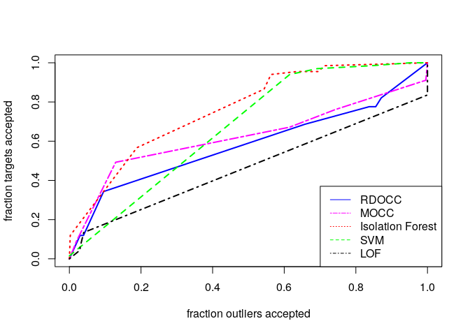

```r
png(filename="roc_u2r_all.png")
plot(x_u2r_rdc,y_u2r_rdc,col="blue",type="l",lwd=2,
     xlab="fraction outliers accepted",ylab="fraction targets accepted")
lines(x_u2r_mocc,y_u2r_mocc,col="magenta",type="l",lty="twodash",lwd=2)
lines(x_u2r_rf,y_u2r_rf,col="red",type="l",lty = "dotted", lwd=2)
lines(x_u2r_svm,y_u2r_svm,col="green",type="l",lty = "dashed", lwd=2)
lines(x_u2r_lof,y_u2r_lof,col="black",type="l", lty = "dotdash", lwd=2)
legend("bottomright",legend=c("RDOCC","MOCC","Isolation Forest","SVM","LOF"),
       lty=c("solid","twodash","dotted","dashed","dotdash"),
       col=c("blue","magenta","red","green","black"))
invisible(dev.off())

#compare ROC/AUC
plot(x_u2r_rdc,y_u2r_rdc,col="blue",type="l",lwd=2,
     xlab="fraction outliers accepted",ylab="fraction targets accepted")
lines(x_u2r_mocc,y_u2r_mocc,col="magenta",type="l",lty="twodash",lwd=2)
lines(x_u2r_rf,y_u2r_rf,col="red",type="l",lty = "dotted", lwd=2)
lines(x_u2r_svm,y_u2r_svm,col="green",type="l",lty = "dashed", lwd=2)
lines(x_u2r_lof,y_u2r_lof,col="black",type="l", lty = "dotdash", lwd=2)
legend("bottomright",legend=c("RDOCC","MOCC","Isolation Forest","SVM","LOF"),
       lty=c("solid","twodash","dotted","dashed","dotdash"),
       col=c("blue","magenta","red","green","black"))
```

```r
dfauc_u2r <- data.frame(class = c("RDOCC","MOCC","Isolation Forest","SVM","LOF"),
                        AUC = c(auc_u2r_rdc, auc_u2r_mocc, auc_u2r_rf,
                                auc_u2r_svm, auc_u2r_lof))
print(dfauc_u2r)
```

```
##              class       AUC
## 1            RDOCC 0.5806300
## 2             MOCC 0.6226657
## 3 Isolation Forest 0.7637104
## 4              SVM 0.6709336
## 5              LOF 0.4673134
```

## R2L-against-all

Set up the class “R2L” versus all other classes, and create a small training set and validation set for tuning Hyperparameters of different classifiers.

```r
A <- a[a$label==4,]
B <- a[a$label!=4,]
A$label <- rep(0,dim(A)[1]) #targets
B$label <- rep(1,dim(B)[1]) #outliers
za <- A
mean_r2l <- apply(A[,-ncol(A)],2,mean)

#rearrange labels (test set)
zb <- b
zb$label[zb$label!=4] <- 1
zb$label[zb$label==4] <- 0

a0 <- A
a1 <- B
ind0 <- sample(c(1:dim(a0)[1]),size=min(1000,dim(a0)[1]),replace=FALSE)
ind1 <- sample(c(1:dim(a1)[1]),size=min(1000,dim(a1)[1]),replace=FALSE)
a_val <- rbind(a0[ind0[1:min(500,floor(length(ind0)/2))],],
               a1[ind1[1:min(500,floor(length(ind1)/2))],])
a_train <- rbind(a0[ind0[(min(500,floor(length(ind0)/2))+1):min(1000,length(ind0))],],
                         a1[ind1[(min(500,floor(length(ind1)/2))+1):min(1000,length(ind1))],])
```

### Relative density one-class classifier (RDOCC)

Train a relative density one-class classifier on R2L-vs.-all case. The value of the hyperparameters are estimated in the same manner as described previously. Finally, the ROC curve and the AUC value are computed and stored.

```r
k <- seq(1,min(sum(a_train[,ncol(a_train)]==0),20),by=2)
fracrej <- seq(0.01,0.3,length.out = 10)
h <- seq(0.01,10,length.out = 10)

l <- tune_rdc(a_train,a_val,fracrej,k,h,verbose=FALSE)
fracrej_opt <- l$fracrej_opt
k_opt <- l$k_opt
h_opt <- l$h_opt

Yl <- za
out <- rdocc_scalable(as.matrix(Yl),as.matrix(zb), h=h_opt, k=k_opt,
                      fracrej = fracrej_opt, verbose=FALSE)
pred <- out[[1]]
cf <- confusionMatrix(factor(pred,levels=c(0,1)),
                      factor(zb[,ncol(zb)],levels=c(0,1)), positive="1")
cntR2L_rdc <- as.numeric(pred==0) #counter for R2L attack
print(cf)
```

```
## Confusion Matrix and Statistics
##
##           Reference
## Prediction     0     1
##          0   704   365
##          1  2183 19292
##
##                Accuracy : 0.887
##                  95% CI : (0.8828, 0.8911)
##     No Information Rate : 0.8719
##     P-Value [Acc > NIR] : 3.374e-12
##
##                   Kappa : 0.308
##
##  Mcnemar's Test P-Value : < 2.2e-16
##
##             Sensitivity : 0.9814
##             Specificity : 0.2439
##          Pos Pred Value : 0.8983
##          Neg Pred Value : 0.6586
##              Prevalence : 0.8719
##          Detection Rate : 0.8557
##    Detection Prevalence : 0.9526
##       Balanced Accuracy : 0.6126
##
##        'Positive' Class : 1
##
```

```r
#roc: vary fracrej parameter and test performance on test set
R <- c(seq(1,0.1,length.out = 5),seq(0.09,0,length.out=5))
error_inliers <- error_outliers <- numeric(0)
for (i in seq_along(R)){
  l <- rdocc_scalable(as.matrix(Yl), as.matrix(zb), h=h_opt, k=k_opt,
                      fracrej = R[i],verbose=FALSE)
  L <- l[[1]]
  error_outliers[i] <- sum(L==0 & zb[,ncol(zb)]==1)
  error_inliers[i] <- sum(L==1 & zb[,ncol(zb)]==0)
}

y_r2l_rdc <- 1 - (error_inliers / sum(zb[,ncol(zb)]==0)) #frac targets accepted
x_r2l_rdc <- (error_outliers / sum(zb[,ncol(zb)]==1)) #frac outliers accepted
auc_r2l_rdc <- auc(x_r2l_rdc,y_r2l_rdc)
```

### Median one-class classifier (MOCC)

Train MOCC on R2L-vs.-all case. the hyperparameters of the classifier are estimated in the same manner as described previously. Finally, the ROC curve and the AUC value are computed and stored.

```r
k <- seq(1,min(sum(a_train[,ncol(a_train)]==0),20),by=2)
fracrej <- seq(0.01,0.3,length.out = 10)

l <- tune_mocc(a_train,a_val,fracrej,k,verbose=FALSE)
fracrej_opt <- l$fracrej_opt
k_opt <- l$k_opt

Yl <- za
out <- mocc_scalable(as.matrix(Yl),as.matrix(zb), k=k_opt,
                      fracrej=fracrej_opt, verbose=FALSE)
pred <- out[[1]]
cf <- confusionMatrix(factor(pred,levels=c(0,1)),
                      factor(zb[,ncol(zb)],levels=c(0,1)), positive="1")
cntR2L_mocc <- as.numeric(pred==0)
print(cf)
```

```
## Confusion Matrix and Statistics
##
##           Reference
## Prediction     0     1
##          0   168    10
##          1  2719 19647
##
##                Accuracy : 0.8789
##                  95% CI : (0.8746, 0.8832)
##     No Information Rate : 0.8719
##     P-Value [Acc > NIR] : 0.0007845
##
##                   Kappa : 0.0962
##
##  Mcnemar's Test P-Value : < 2.2e-16
##
##             Sensitivity : 0.99949
##             Specificity : 0.05819
##          Pos Pred Value : 0.87843
##          Neg Pred Value : 0.94382
##              Prevalence : 0.87194
##          Detection Rate : 0.87150
##    Detection Prevalence : 0.99210
##       Balanced Accuracy : 0.52884
##
##        'Positive' Class : 1
##
```

```r
#roc: vary fracrej parameter and test performance on test set
R <- c(seq(1,0.1,length.out = 5),seq(0.09,0,length.out=5))
error_inliers <- error_outliers <- numeric(0)
for (i in seq_along(R)){
  l <- mocc_scalable(as.matrix(Yl), as.matrix(zb), k=k_opt,
                      fracrej = R[i], verbose=FALSE)
  L <- l[[1]]
  error_outliers[i] <- sum(L==0 & zb[,ncol(zb)]==1)
  error_inliers[i] <- sum(L==1 & zb[,ncol(zb)]==0)
}

y_r2l_mocc <- 1 - (error_inliers / sum(zb[,ncol(zb)]==0)) #frac targets accepted
x_r2l_mocc <- (error_outliers / sum(zb[,ncol(zb)]==1)) #frac outliers accepted
auc_r2l_mocc <- auc(x_r2l_mocc,y_r2l_mocc)
```

### Isolation forest

Train an isolation forest classifier on R2L-vs.-all case. The value of the hyperparameters are estimated in the same manner as described previously. Finally, the ROC curve and the AUC value are computed and stored.

```r
#optimize hyperparameters
fracrej <- seq(0.01,0.3,length.out = 10)

l <- suppressMessages(tune_iforest(a_train,a_val,fracrej,verbose=FALSE))
fracrej_opt <- l$fracrej_opt

Yl <- za
x <- as.data.frame(Yl)
y <- as.data.frame(zb)
colnames(y) <- colnames(x)

out <- suppressMessages(iForest(x,y,fracrej = fracrej_opt, sample_size = dim(x)[1]))
pred <- out[[1]]
cf <- confusionMatrix(factor(pred,levels=c(0,1)),
                      factor(y[,ncol(y)],levels=c(0,1)), positive="1")
cntR2L_rf <- as.numeric(pred==0) #counter for R2L attack
print(cf)
```

```
## Confusion Matrix and Statistics
##
##           Reference
## Prediction     0     1
##          0   328    72
##          1  2559 19585
##
##                Accuracy : 0.8833
##                  95% CI : (0.879, 0.8875)
##     No Information Rate : 0.8719
##     P-Value [Acc > NIR] : 1.257e-07
##
##                   Kappa : 0.1738
##
##  Mcnemar's Test P-Value : < 2.2e-16
##
##             Sensitivity : 0.9963
##             Specificity : 0.1136
##          Pos Pred Value : 0.8844
##          Neg Pred Value : 0.8200
##              Prevalence : 0.8719
##          Detection Rate : 0.8687
##    Detection Prevalence : 0.9823
##       Balanced Accuracy : 0.5550
##
##        'Positive' Class : 1
##
```

```r
#roc
R <- c(seq(1,0.1,length.out = 5),seq(0.09,0,length.out=5))
error_inliers <- error_outliers <- numeric(0)
for (i in seq_along(R)){
  l <- suppressMessages(iForest(x,y,fracrej=R[i], sample_size = dim(x)[1]))
  L <- l[[1]]
  error_outliers[i] <- sum(L==0 & y[,ncol(y)]==1)
  error_inliers[i] <- sum(L==1 & y[,ncol(y)]==0)
}

y_r2l_rf <- 1 - (error_inliers / sum(y[,ncol(y)]==0)) #frac targets accepted
x_r2l_rf <- (error_outliers / sum(y[,ncol(y)]==1)) #frac outliers accepted
auc_r2l_rf <- auc(x_r2l_rf,y_r2l_rf)
```

### Support vector machine

Train a support vector machine on R2L-vs.-all case. The value of hyperparameterss are estimated in the same manner as described previously. Finally, the ROC curve and the AUC value are computed and stored.

```r
#optimize hyperparameters
nu <- seq(0.01,0.99,length.out = 40)
gamma <- seq(0.01,0.99,length.out = 40)

l <- tune_svm(a_train,a_val,nu,gamma,verbose=FALSE)
nu_opt <- l$nu_opt
gamma_opt <- l$gamma_opt

Yl <- za
x <- as.data.frame(Yl)
y <- as.data.frame(zb)
colnames(y) <- colnames(x)

model <- svm(x = x[,-ncol(x)], y = x[,ncol(x)], type="one-classification",kernel="radial",
             nu=nu_opt,gamma = gamma_opt)

#Test the model on test set
pred <- predict(model, y[,-ncol(y)])
cf <- confusionMatrix(factor(as.numeric(!pred),levels=c(0,1)),
                      factor(y[,ncol(y)],levels=c(0,1)), positive="1")
cntR2L_svm <- as.numeric(!pred==0) #counter for R2L attack
print(cf)
```

```
## Confusion Matrix and Statistics
##
##           Reference
## Prediction     0     1
##          0   655   485
##          1  2232 19172
##
##                Accuracy : 0.8795
##                  95% CI : (0.8752, 0.8837)
##     No Information Rate : 0.8719
##     P-Value [Acc > NIR] : 0.0003311
##
##                   Kappa : 0.2726
##
##  Mcnemar's Test P-Value : < 2.2e-16
##
##             Sensitivity : 0.9753
##             Specificity : 0.2269
##          Pos Pred Value : 0.8957
##          Neg Pred Value : 0.5746
##              Prevalence : 0.8719
##          Detection Rate : 0.8504
##    Detection Prevalence : 0.9494
##       Balanced Accuracy : 0.6011
##
##        'Positive' Class : 1
##
```

```r
#roc
predtest <- predict(model,y[,-ncol(y)],decision.values=TRUE)
lp <- attributes(predtest)$decision.values
R <- seq(max(lp),min(lp),length.out=10)
error_inliers <- error_outliers <- numeric(0)
for (i in seq_along(R)){
  L <- as.numeric(lp < R[i])
  error_outliers[i] <- sum(L==0 & y[,ncol(y)]==1)
  error_inliers[i] <- sum(L==1 & y[,ncol(y)]==0)
}
y_r2l_svm <- 1 - (error_inliers / sum(y[,ncol(y)]==0)) #frac targets accepted
x_r2l_svm <- (error_outliers / sum(y[,ncol(y)]==1)) #frac outliers accepted
auc_r2l_svm <- auc(x_r2l_svm,y_r2l_svm)
```

### Local outlier factor

Train a local outlier factor classifier on R2L-vs.-all case. The value of hyperparameterss are estimated in the same manner as described previously. Finally, the ROC curve and the AUC value are computed and stored.

```r
#optimize hyperparameters
a_val <- rbind(a0[ind0[1:min(50,floor(length(ind0)/2))],],
               a1[ind1[1:min(50,floor(length(ind1)/2))],])
a_train <- rbind(a0[ind0[(min(50,floor(length(ind0)/2))+1):min(100,length(ind0))],],
                         a1[ind1[(min(50,floor(length(ind1)/2))+1):min(100,length(ind1))],])

fracrej <- seq(0.01,0.3,length.out = 10)
k <- seq(2,min(20,sum(a_train$label==0)-1),by=3)

l <- tune_lof(a_train,a_val,fracrej,k,verbose=FALSE)
fracrej_opt <- l$fracrej_opt
k_opt <- l$k_opt

b0 <- zb[zb$label==0,]
b1 <- zb[zb$label==1,]
ind0 <- sample(c(1:dim(b0)[1]),size=min(100,dim(b0)[1]),replace=FALSE)
ind1 <- sample(c(1:dim(b1)[1]),size=min(100,dim(b1)[1]),replace=FALSE)
b_test <- rbind(b0[ind0,],b1[ind1,])

Yl <- a_train[a_train$label==0,]
x <- as.data.frame(Yl)
y <- as.data.frame(b_test)
colnames(y) <- colnames(x)

out <- lof_wrapper(x, y, k = k_opt, fracrej = fracrej_opt, cores=1)
pred <- out[[1]]
cf <- confusionMatrix(factor(pred,levels=c(0,1)),
                      factor(y[,ncol(y)],levels=c(0,1)), positive="1")
cntR2L_lof <- as.numeric(pred==0) #counter for R2L attack
print(cf)
```

```
## Confusion Matrix and Statistics
##
##           Reference
## Prediction   0   1
##          0  35   0
##          1  65 100
##
##                Accuracy : 0.675
##                  95% CI : (0.6053, 0.7394)
##     No Information Rate : 0.5
##     P-Value [Acc > NIR] : 4.164e-07
##
##                   Kappa : 0.35
##
##  Mcnemar's Test P-Value : 2.051e-15
##
##             Sensitivity : 1.0000
##             Specificity : 0.3500
##          Pos Pred Value : 0.6061
##          Neg Pred Value : 1.0000
##              Prevalence : 0.5000
##          Detection Rate : 0.5000
##    Detection Prevalence : 0.8250
##       Balanced Accuracy : 0.6750
##
##        'Positive' Class : 1
##
```

```r
#roc
R <- c(seq(1,0.1,length.out = 5),seq(0.09,0,length.out=5))
error_inliers <- error_outliers <- numeric(0)
for (i in seq_along(R)){
  l <- lof_wrapper(x, y, k = k_opt, fracrej = R[i], cores=1)
  L <- l[[1]]
  error_outliers[i] <- sum(L==0 & y[,ncol(y)]==1)
  error_inliers[i] <- sum(L==1 & y[,ncol(y)]==0)
}

y_r2l_lof<- 1 - (error_inliers / sum(y[,ncol(y)]==0)) #frac targets accepted
x_r2l_lof <- (error_outliers / sum(y[,ncol(y)]==1)) #frac outliers accepted
auc_r2l_lof <- auc(x_r2l_lof,y_r2l_lof)
```

### ROC/AUC comparison

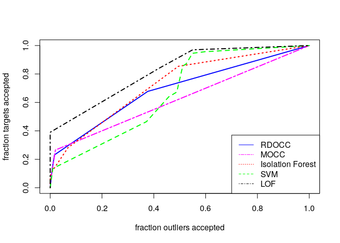

```r
png(filename="roc_r2l_all.png")
plot(x_r2l_rdc,y_r2l_rdc,col="blue",type="l",lwd=2,
     xlab="fraction outliers accepted",ylab="fraction targets accepted")
lines(x_r2l_mocc,y_r2l_mocc,col="magenta",type="l",lty = "twodash", lwd=2)
lines(x_r2l_rf,y_r2l_rf,col="red",type="l",lty = "dotted", lwd=2)
lines(x_r2l_svm,y_r2l_svm,col="green",type="l",lty = "dashed", lwd=2)
lines(x_r2l_lof,y_r2l_lof,col="black",type="l", lty = "dotdash", lwd=2)
legend("bottomright",legend=c("RDOCC","MOCC","Isolation Forest","SVM","LOF"),
       lty=c("solid","twodash","dotted","dashed","dotdash"),
       col=c("blue","magenta","red","green","black"))
invisible(dev.off())

#compare ROC/AUC
plot(x_r2l_rdc,y_r2l_rdc,col="blue",type="l",lwd=2,
     xlab="fraction outliers accepted",ylab="fraction targets accepted")
lines(x_r2l_mocc,y_r2l_mocc,col="magenta",type="l",lty = "twodash", lwd=2)
lines(x_r2l_rf,y_r2l_rf,col="red",type="l",lty = "dotted", lwd=2)
lines(x_r2l_svm,y_r2l_svm,col="green",type="l",lty = "dashed", lwd=2)
lines(x_r2l_lof,y_r2l_lof,col="black",type="l", lty = "dotdash", lwd=2)
legend("bottomright",legend=c("RDOCC","MOCC","Isolation Forest","SVM","LOF"),
       lty=c("solid","twodash","dotted","dashed","dotdash"),
       col=c("blue","magenta","red","green","black"))
```

```r
dfauc_r2l <- data.frame(class = c("RDOCC","MOCC","Isolation Forest","SVM","LOF"),
                        AUC = c(auc_r2l_rdc, auc_r2l_mocc, auc_r2l_rf,
                                auc_r2l_svm, auc_r2l_lof))
print(dfauc_r2l)
```

```
##              class       AUC
## 1            RDOCC 0.6886062
## 2             MOCC 0.6229292
## 3 Isolation Forest 0.7232004
## 4              SVM 0.6678023
## 5              LOF 0.8192000
```

## Majority vote

A majority vote among the 5 classifiers decides the label of a given test object. Ties are broken by assigning to the class with the nearest mean from among the classes that are in tie. In case an object is rejected as outlier by all 5 classifiers, it is assigned to the class with the nearest mean.

### Relative density one-class classifier (RDOCC)

```r
#majority vote: rdc
votes <- cbind(cntN_rdc, cntProbe_rdc, cntDoS_rdc, cntU2R_rdc, cntR2L_rdc) #binary
predicted_labels <- rep(NA,dim(xtst)[1])
s <- apply(votes,1,sum)
idx <- which(s==1)
predicted_labels[idx] <- (max.col(votes[idx,])-1)

M <- rbind(mean_normal, mean_probe, mean_dos, mean_u2r, mean_r2l)
idx0 <- which(s==0)
d <- cdist(b[idx0,-ncol(b)], M, metric="euclidean")
predicted_labels[idx0] <- (apply(d,1,which.min)-1)

idx_tie <- which(s>1)
for (i in seq_along(idx_tie)){
  q <- which(votes[idx_tie[i],]==1)
  t <- M[q,]
  d <- cdist(b[idx_tie[i],-ncol(b),drop=FALSE], t, metric="euclidean")
  v <- apply(d,1,which.min)
  predicted_labels[idx_tie[i]] <- (q[v]-1)
}

#showing voting stats
df_rdc <- data.frame(unique_label = length(idx), no_label = length(idx0), tie = length(idx_tie))
print(df_rdc)
```

```
##   unique_label no_label   tie
## 1         7147     1497 13900
```

#### Confusion matrix

Compute the confusion matrix over all 5 classes.

```r
cf <- confusionMatrix(factor(predicted_labels,levels=c(0,1,2,3,4)),
                      factor(b[,ncol(b)],levels=c(0,1,2,3,4)))
print(cf)
```

```
## Confusion Matrix and Statistics
##
##           Reference
## Prediction    0    1    2    3    4
##          0 8756  321 1410   43 1633
##          1  678 1775  635    0   14
##          2  165  270 5397    0   82
##          3   49   55   13   17  506
##          4   63    0    3    7  652
##
## Overall Statistics
##
##                Accuracy : 0.7362
##                  95% CI : (0.7304, 0.7419)
##     No Information Rate : 0.4308
##     P-Value [Acc > NIR] : < 2.2e-16
##
##                   Kappa : 0.6014
##
##  Mcnemar's Test P-Value : < 2.2e-16
##
## Statistics by Class:
##
##                      Class: 0 Class: 1 Class: 2  Class: 3 Class: 4
## Sensitivity            0.9017  0.73317   0.7237 0.2537313  0.22584
## Specificity            0.7345  0.93406   0.9657 0.9722828  0.99629
## Pos Pred Value         0.7199  0.57221   0.9126 0.0265625  0.89931
## Neg Pred Value         0.9080  0.96677   0.8761 0.9977173  0.89757
## Prevalence             0.4308  0.10739   0.3308 0.0029720  0.12806
## Detection Rate         0.3884  0.07873   0.2394 0.0007541  0.02892
## Detection Prevalence   0.5395  0.13760   0.2623 0.0283889  0.03216
## Balanced Accuracy      0.8181  0.83361   0.8447 0.6130071  0.61106
```

#### ROC/AUC

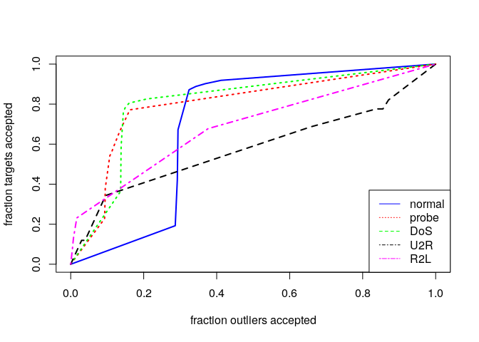

```r
png(filename="roc_rdocc.png")
plot(x_normal_rdc,y_normal_rdc,col="blue",type="l",lwd=2,
     xlab="fraction outliers accepted",ylab="fraction targets accepted")
lines(x_probe_rdc,y_probe_rdc,col="red",type="l",lty = "dotted", lwd=2)
lines(x_dos_rdc,y_dos_rdc,col="green",type="l",lty = "dotted", lwd=2)
lines(x_u2r_rdc,y_u2r_rdc,col="black",type="l",lty = "dashed", lwd=2)
lines(x_r2l_rdc,y_r2l_rdc,col="magenta",type="l", lty = "dotdash", lwd=2)
legend("bottomright",legend=c("normal","probe","DoS","U2R","R2L"),
       lty=c("solid","dotted","dashed","dotdash","twodash"),
       col=c("blue","red","green","black","magenta"))
invisible(dev.off())

#compare ROC/AUC
plot(x_normal_rdc,y_normal_rdc,col="blue",type="l",lwd=2,
     xlab="fraction outliers accepted",ylab="fraction targets accepted")
lines(x_probe_rdc,y_probe_rdc,col="red",type="l",lty = "dotted", lwd=2)
lines(x_dos_rdc,y_dos_rdc,col="green",type="l",lty = "dotted", lwd=2)
lines(x_u2r_rdc,y_u2r_rdc,col="black",type="l",lty = "dashed", lwd=2)
lines(x_r2l_rdc,y_r2l_rdc,col="magenta",type="l", lty = "dotdash", lwd=2)
legend("bottomright",legend=c("normal","probe","DoS","U2R","R2L"),
       lty=c("solid","dotted","dashed","dotdash","twodash"),
       col=c("blue","red","green","black","magenta"))
```

```r
dfauc_rdc <- data.frame(class = c("normal","probe","DoS","U2R","R2L"),
                        AUC = c(auc_normal_rdc,auc_probe_rdc,
                                auc_dos_rdc,auc_u2r_rdc,auc_r2l_rdc))
print(dfauc_rdc)
```

```
##    class       AUC
## 1 normal 0.6967809
## 2  probe 0.7953461
## 3    DoS 0.8042089
## 4    U2R 0.5806300
## 5    R2L 0.6886062
```

### Median one-class classifier (MOCC)

```r
#majority vote: mocc
votes <- cbind(cntN_mocc, cntProbe_mocc, cntDoS_mocc, cntU2R_mocc, cntR2L_mocc) #binary
predicted_labels <- rep(NA,dim(xtst)[1])
s <- apply(votes,1,sum)
idx <- which(s==1)
predicted_labels[idx] <- (max.col(votes[idx,])-1)

M <- rbind(mean_normal, mean_probe, mean_dos, mean_u2r, mean_r2l)
idx0 <- which(s==0)
d <- cdist(b[idx0,-ncol(b)], M, metric="euclidean")
predicted_labels[idx0] <- (apply(d,1,which.min)-1)

idx_tie <- which(s>1)
for (i in seq_along(idx_tie)){
  q <- which(votes[idx_tie[i],]==1)
  t <- M[q,]
  d <- cdist(b[idx_tie[i],-ncol(b),drop=FALSE], t, metric="euclidean")
  v <- apply(d,1,which.min)
  predicted_labels[idx_tie[i]] <- (q[v]-1)
}

#showing voting stats
df_mocc <- data.frame(unique_label = length(idx), no_label = length(idx0),
                      tie = length(idx_tie))
print(df_mocc)
```

```
##   unique_label no_label   tie
## 1         8970     3485 10089
```

#### Confusion matrix

Compute the confusion matrix over all 5 classes.

```r
cf <- confusionMatrix(factor(predicted_labels,levels=c(0,1,2,3,4)),
                      factor(b[,ncol(b)],levels=c(0,1,2,3,4)))
print(cf)
```

```
## Confusion Matrix and Statistics
##
##           Reference
## Prediction    0    1    2    3    4
##          0 8677  291  461   11  981
##          1  213 1688  531    0   14
##          2   60  232 5674    0    0
##          3  752  210  792   55 1737
##          4    9    0    0    1  155
##
## Overall Statistics
##
##                Accuracy : 0.7208
##                  95% CI : (0.7149, 0.7266)
##     No Information Rate : 0.4308
##     P-Value [Acc > NIR] : < 2.2e-16
##
##                   Kappa : 0.6013
##
##  Mcnemar's Test P-Value : NA
##
## Statistics by Class:
##
##                      Class: 0 Class: 1 Class: 2 Class: 3 Class: 4
## Sensitivity            0.8935  0.69723   0.7608 0.820896 0.053689
## Specificity            0.8641  0.96233   0.9806 0.844686 0.999491
## Pos Pred Value         0.8326  0.69011   0.9511 0.015510 0.939394
## Neg Pred Value         0.9147  0.96353   0.8924 0.999368 0.877921
## Prevalence             0.4308  0.10739   0.3308 0.002972 0.128061
## Detection Rate         0.3849  0.07488   0.2517 0.002440 0.006875
## Detection Prevalence   0.4623  0.10850   0.2646 0.157292 0.007319
## Balanced Accuracy      0.8788  0.82978   0.8707 0.832791 0.526590
```

#### ROC/AUC

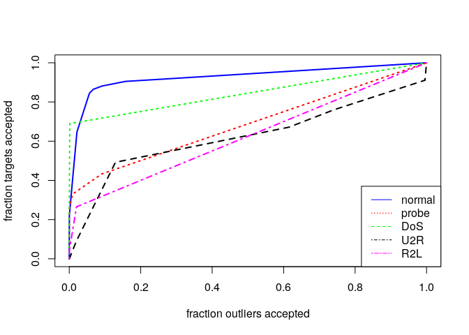

```r
png(filename="roc_mocc.png")
plot(x_normal_mocc,y_normal_mocc,col="blue",type="l",lwd=2,
     xlab="fraction outliers accepted",ylab="fraction targets accepted")
lines(x_probe_mocc,y_probe_mocc,col="red",type="l",lty = "dotted", lwd=2)
lines(x_dos_mocc,y_dos_mocc,col="green",type="l",lty = "dotted", lwd=2)
lines(x_u2r_mocc,y_u2r_mocc,col="black",type="l",lty = "dashed", lwd=2)
lines(x_r2l_mocc,y_r2l_mocc,col="magenta",type="l", lty = "dotdash", lwd=2)
legend("bottomright",legend=c("normal","probe","DoS","U2R","R2L"),
       lty=c("solid","dotted","dashed","dotdash","twodash"),
       col=c("blue","red","green","black","magenta"))
invisible(dev.off())

#compare ROC/AUC
plot(x_normal_mocc,y_normal_mocc,col="blue",type="l",lwd=2,
     xlab="fraction outliers accepted",ylab="fraction targets accepted")
lines(x_probe_mocc,y_probe_mocc,col="red",type="l",lty = "dotted", lwd=2)
lines(x_dos_mocc,y_dos_mocc,col="green",type="l",lty = "dotted", lwd=2)
lines(x_u2r_mocc,y_u2r_mocc,col="black",type="l",lty = "dashed", lwd=2)
lines(x_r2l_mocc,y_r2l_mocc,col="magenta",type="l", lty = "dotdash", lwd=2)
legend("bottomright",legend=c("normal","probe","DoS","U2R","R2L"),
       lty=c("solid","dotted","dashed","dotdash","twodash"),
       col=c("blue","red","green","black","magenta"))
```

```r
dfauc_mocc <- data.frame(class = c("normal","probe","DoS","U2R","R2L"),
                        AUC = c(auc_normal_mocc, auc_probe_mocc,
                                auc_dos_mocc, auc_u2r_mocc, auc_r2l_mocc))
print(dfauc_mocc)
```

```
##    class       AUC
## 1 normal 0.9271178
## 2  probe 0.6851716
## 3    DoS 0.8443768
## 4    U2R 0.6226657
## 5    R2L 0.6229292
```

### Isolation forest

```r
#majority vote: isf
votes <- cbind(cntN_rf, cntProbe_rf, cntDoS_rf, cntU2R_rf, cntR2L_rf) #binary
predicted_labels <- rep(NA,dim(xtst)[1])
s <- apply(votes,1,sum)
idx <- which(s==1)
predicted_labels[idx] <- (max.col(votes[idx,])-1)

M <- rbind(mean_normal, mean_probe, mean_dos, mean_u2r, mean_r2l)
idx0 <- which(s==0)
d <- cdist(b[idx0,-ncol(b)], M, metric="euclidean")
predicted_labels[idx0] <- (apply(d,1,which.min)-1)

idx_tie <- which(s>1)
for (i in seq_along(idx_tie)){
  q <- which(votes[idx_tie[i],]==1)
  t <- M[q,]
  d <- cdist(b[idx_tie[i],-ncol(b),drop=FALSE], t, metric="euclidean")
  v <- apply(d,1,which.min)
  predicted_labels[idx_tie[i]] <- (q[v]-1)
}

df_rf <- data.frame(unique_label = length(idx), no_label = length(idx0), tie = length(idx_tie))
print(df_rf)
```

```
##   unique_label no_label  tie
## 1        15001     2544 4999
```

#### Confusion matrix

Compute the confusion matrix over all 5 classes.

```r
cf <- confusionMatrix(factor(predicted_labels,levels=c(0,1,2,3,4)),
                      factor(b[,ncol(b)],levels=c(0,1,2,3,4)))
print(cf)
```

```
## Confusion Matrix and Statistics
##
##           Reference
## Prediction    0    1    2    3    4
##          0 8931  398  987   22 2110
##          1  651 1780  535    0   12
##          2   85  228 5605    0    0
##          3   28   15  331   40  358
##          4   16    0    0    5  407
##
## Overall Statistics
##
##                Accuracy : 0.7436
##                  95% CI : (0.7378, 0.7493)
##     No Information Rate : 0.4308
##     P-Value [Acc > NIR] : < 2.2e-16
##
##                   Kappa : 0.6106
##
##  Mcnemar's Test P-Value : NA
##
## Statistics by Class:
##
##                      Class: 0 Class: 1 Class: 2 Class: 3 Class: 4
## Sensitivity            0.9197  0.73523   0.7515 0.597015  0.14098
## Specificity            0.7259  0.94047   0.9793 0.967433  0.99893
## Pos Pred Value         0.7175  0.59772   0.9471 0.051813  0.95093
## Neg Pred Value         0.9227  0.96724   0.8885 0.998760  0.88786
## Prevalence             0.4308  0.10739   0.3308 0.002972  0.12806
## Detection Rate         0.3962  0.07896   0.2486 0.001774  0.01805
## Detection Prevalence   0.5522  0.13210   0.2625 0.034244  0.01899
## Balanced Accuracy      0.8228  0.83785   0.8654 0.782224  0.56995
```

#### ROC/AUC

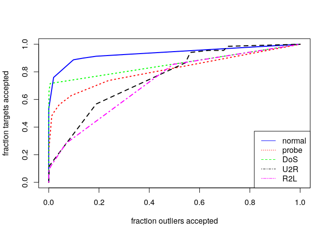

```r
png(filename="roc_isf.png")
plot(x_normal_rf,y_normal_rf,col="blue",type="l",lwd=2,
     xlab="fraction outliers accepted",ylab="fraction targets accepted")
lines(x_probe_rf,y_probe_rf,col="red",type="l",lty = "dotted", lwd=2)
lines(x_dos_rf,y_dos_rf,col="green",type="l",lty = "dotted", lwd=2)
lines(x_u2r_rf,y_u2r_rf,col="black",type="l",lty = "dashed", lwd=2)
lines(x_r2l_rf,y_r2l_rf,col="magenta",type="l", lty = "dotdash", lwd=2)
legend("bottomright",legend=c("normal","probe","DoS","U2R","R2L"),
       lty=c("solid","dotted","dashed","dotdash","twodash"),
       col=c("blue","red","green","black","magenta"))
invisible(dev.off())

#compare ROC/AUC
plot(x_normal_rf,y_normal_rf,col="blue",type="l",lwd=2,
     xlab="fraction outliers accepted",ylab="fraction targets accepted")
lines(x_probe_rf,y_probe_rf,col="red",type="l",lty = "dotted", lwd=2)
lines(x_dos_rf,y_dos_rf,col="green",type="l",lty = "dotted", lwd=2)
lines(x_u2r_rf,y_u2r_rf,col="black",type="l",lty = "dashed", lwd=2)
lines(x_r2l_rf,y_r2l_rf,col="magenta",type="l", lty = "dotdash", lwd=2)
legend("bottomright",legend=c("normal","probe","DoS","U2R","R2L"),
       lty=c("solid","dotted","dashed","dotdash","twodash"),
       col=c("blue","red","green","black","magenta"))
```

```r
dfauc_rf <- data.frame(class = c("normal","probe","DoS","U2R","R2L"),
                        AUC = c(auc_normal_rf, auc_probe_rf, auc_dos_rf,
                                auc_u2r_rf, auc_r2l_rf))
print(dfauc_rf)
```

```
##    class       AUC
## 1 normal 0.9350764
## 2  probe 0.8114577
## 3    DoS 0.8567667
## 4    U2R 0.7637104
## 5    R2L 0.7232004
```

### Support vector machine

```r
#majority vote: svm
votes <- cbind(cntN_svm, cntProbe_svm, cntDoS_svm, cntU2R_svm, cntR2L_svm) #binary
predicted_labels <- rep(NA,dim(xtst)[1])
s <- apply(votes,1,sum)
idx <- which(s==1)
predicted_labels[idx] <- (max.col(votes[idx,])-1)

M <- rbind(mean_normal, mean_probe, mean_dos, mean_u2r, mean_r2l)
idx0 <- which(s==0)
d <- cdist(b[idx0,-ncol(b)], M, metric="euclidean")
predicted_labels[idx0] <- (apply(d,1,which.min)-1)

idx_tie <- which(s>1)
for (i in seq_along(idx_tie)){
  q <- which(votes[idx_tie[i],]==1)
  t <- M[q,]
  d <- cdist(b[idx_tie[i],-ncol(b),drop=FALSE], t, metric="euclidean")
  v <- apply(d,1,which.min)
  predicted_labels[idx_tie[i]] <- (q[v]-1)
}

df_svm <- data.frame(unique_label = length(idx), no_label = length(idx0), tie = length(idx_tie))
print(df_svm)
```

```
##   unique_label no_label   tie
## 1         9569     1489 11486
```

#### Confusion matrix

Compute the confusion matrix over all 5 classes.

```r
cf <- confusionMatrix(factor(predicted_labels,levels=c(0,1,2,3,4)),
                      factor(b[,ncol(b)],levels=c(0,1,2,3,4)))
print(cf)
```

```
## Confusion Matrix and Statistics
##
##           Reference
## Prediction    0    1    2    3    4
##          0 8957  329 1303   25 2078
##          1  633 1958  704    0   31
##          2   62  134 5451    0    0
##          3   20    0    0   35   22
##          4   39    0    0    7  756
##
## Overall Statistics
##
##                Accuracy : 0.761
##                  95% CI : (0.7554, 0.7666)
##     No Information Rate : 0.4308
##     P-Value [Acc > NIR] : < 2.2e-16
##
##                   Kappa : 0.6347
##
##  Mcnemar's Test P-Value : NA
##
## Statistics by Class:
##
##                      Class: 0 Class: 1 Class: 2 Class: 3 Class: 4
## Sensitivity            0.9224  0.80876   0.7309 0.522388  0.26186
## Specificity            0.7090  0.93202   0.9870 0.998131  0.99766
## Pos Pred Value         0.7057  0.58870   0.9653 0.454545  0.94264
## Neg Pred Value         0.9235  0.97591   0.8812 0.998576  0.90199
## Prevalence             0.4308  0.10739   0.3308 0.002972  0.12806
## Detection Rate         0.3973  0.08685   0.2418 0.001553  0.03353
## Detection Prevalence   0.5630  0.14753   0.2505 0.003416  0.03557
## Balanced Accuracy      0.8157  0.87039   0.8590 0.760260  0.62976
```

#### ROC/AUC

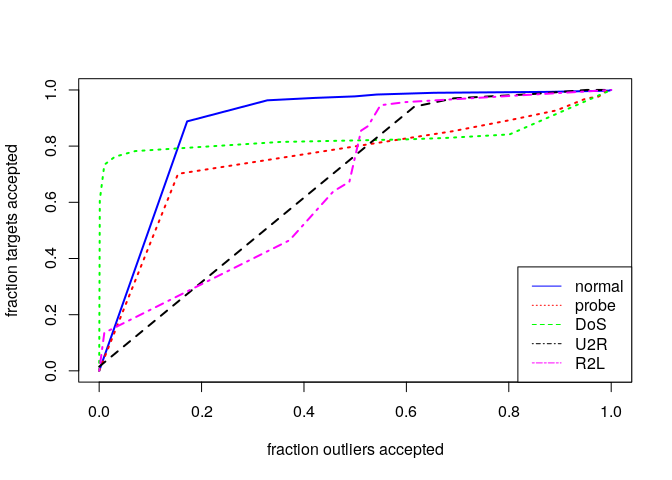

```r
png(filename="roc_svm.png")
plot(x_normal_svm,y_normal_svm,col="blue",type="l",lwd=2,
     xlab="fraction outliers accepted",ylab="fraction targets accepted")
lines(x_probe_svm,y_probe_svm,col="red",type="l",lty = "dotted", lwd=2)
lines(x_dos_svm,y_dos_svm,col="green",type="l",lty = "dotted", lwd=2)
lines(x_u2r_svm,y_u2r_svm,col="black",type="l",lty = "dashed", lwd=2)
lines(x_r2l_svm,y_r2l_svm,col="magenta",type="l", lty = "dotdash", lwd=2)
legend("bottomright",legend=c("normal","probe","DoS","U2R","R2L"),
       lty=c("solid","dotted","dashed","dotdash","twodash"),
       col=c("blue","red","green","black","magenta"))
invisible(dev.off())

#compare ROC/AUC
plot(x_normal_svm,y_normal_svm,col="blue",type="l",lwd=2,
     xlab="fraction outliers accepted",ylab="fraction targets accepted")
lines(x_probe_svm,y_probe_svm,col="red",type="l",lty = "dotted", lwd=2)
lines(x_dos_svm,y_dos_svm,col="green",type="l",lty = "dotted", lwd=2)
lines(x_u2r_svm,y_u2r_svm,col="black",type="l",lty = "dashed", lwd=2)
lines(x_r2l_svm,y_r2l_svm,col="magenta",type="l", lty = "dotdash", lwd=2)
legend("bottomright",legend=c("normal","probe","DoS","U2R","R2L"),
       lty=c("solid","dotted","dashed","dotdash","twodash"),
       col=c("blue","red","green","black","magenta"))
```

```r
dfauc_svm <- data.frame(class = c("normal","probe","DoS","U2R","R2L"),
                        AUC = c(auc_normal_svm, auc_probe_svm, auc_dos_svm,
                                auc_u2r_svm, auc_r2l_svm))
print(dfauc_svm)
```

```
##    class       AUC
## 1 normal 0.8830103
## 2  probe 0.7542257
## 3    DoS 0.8309032
## 4    U2R 0.6709336
## 5    R2L 0.6678023
```

### Local outlier factor

Combining through majority vote cannot be applied in this case because the test set is not fixed in the case of LOF, but is rather a variable subset of the original test set to avoid long runtimes.

```r
# #majority vote: lof
# votes <- cbind(cntN_lof, cntProbe_lof, cntDoS_lof, cntU2R_lof, cntR2L_lof) #binary
# predicted_labels <- rep(NA,dim(xtst)[1])
# s <- apply(votes,1,sum)
# idx <- which(s==1)
# predicted_labels[idx] <- (max.col(votes[idx,])-1)
#
# M <- rbind(mean_normal, mean_probe, mean_dos, mean_u2r, mean_r2l)
# idx0 <- which(s==0)
# d <- cdist(b[idx0,-ncol(b)], M, metric="euclidean")
# predicted_labels[idx0] <- (apply(d,1,which.min)-1)
#
# idx_tie <- which(s>1)
# for (i in seq_along(idx_tie)){
#   q <- which(votes[idx_tie[i],]==1)
#   t <- M[q,]
#   d <- cdist(b[idx_tie[i],-ncol(b),drop=FALSE], t, metric="euclidean")
#   v <- apply(d,1,which.min)
#   predicted_labels[idx_tie[i]] <- (q[v]-1)
# }
#
# df_lof <- data.frame(unique_label = length(idx), no_label = length(idx0), tie = length(idx_tie))
# print(df_lof)
```

#### Confusion matrix

```r
# cf <- confusionMatrix(factor(predicted_labels,levels=c(0,1,2,3,4)),
#                       factor(b[,ncol(b)],levels=c(0,1,2,3,4)))
# print(cf)
```

#### ROC/AUC

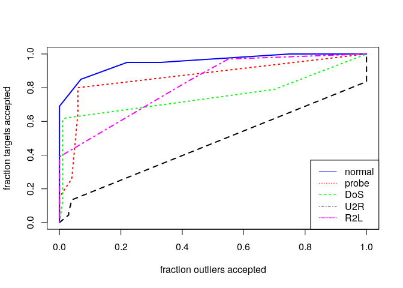

```r
png(filename="roc_lof.png")
plot(x_normal_lof,y_normal_lof,col="blue",type="l",lwd=2,
     xlab="fraction outliers accepted",ylab="fraction targets accepted")
lines(x_probe_lof,y_probe_lof,col="red",type="l",lty = "dotted", lwd=2)
lines(x_dos_lof,y_dos_lof,col="green",type="l",lty = "dotted", lwd=2)
lines(x_u2r_lof,y_u2r_lof,col="black",type="l",lty = "dashed", lwd=2)
lines(x_r2l_lof,y_r2l_lof,col="magenta",type="l", lty = "dotdash", lwd=2)
legend("bottomright",legend=c("normal","probe","DoS","U2R","R2L"),
       lty=c("solid","dotted","dashed","dotdash","twodash"),
       col=c("blue","red","green","black","magenta"))
invisible(dev.off())

#compare ROC/AUC
plot(x_normal_lof,y_normal_lof,col="blue",type="l",lwd=2,
     xlab="fraction outliers accepted",ylab="fraction targets accepted")
lines(x_probe_lof,y_probe_lof,col="red",type="l",lty = "dotted", lwd=2)
lines(x_dos_lof,y_dos_lof,col="green",type="l",lty = "dotted", lwd=2)
lines(x_u2r_lof,y_u2r_lof,col="black",type="l",lty = "dashed", lwd=2)
lines(x_r2l_lof,y_r2l_lof,col="magenta",type="l", lty = "dotdash", lwd=2)
legend("bottomright",legend=c("normal","probe","DoS","U2R","R2L"),
       lty=c("solid","dotted","dashed","dotdash","twodash"),
       col=c("blue","red","green","black","magenta"))
```

```r
dfauc_lof <- data.frame(class = c("normal","probe","DoS","U2R","R2L"),
                        AUC = c(auc_normal_lof, auc_probe_lof, auc_dos_lof,
                                auc_u2r_lof, auc_r2l_lof))
print(dfauc_lof)
```

```
##    class       AUC
## 1 normal 0.9530000
## 2  probe 0.8633000
## 3    DoS 0.7546500
## 4    U2R 0.4673134
## 5    R2L 0.8192000
```